# HTML Embedded Version

### 8.9.2 Selectivity Patterns

The currently defined selectivity patterns, and corresponding required number of parameters, are:

[output not shown]

| AGE BASED SELECTIVITY |  |  |
| --- | --- | --- |
| Pattern | N Parameters | Description |
| 0 | 0 | Selectivity = 1.0 for ages 0+. |
| 10 | 0 | Selectivity = 1.0 for all ages beginning at age 1. If it is desired that age-0 fish be selected, then use pattern #11 and set minimum age to 0.0. |
| 11 | 2 | Selectivity = 1.0 for a specified age range. |
| 12 | 2 | Logistic selectivity. |
| 13 | 8 | Double logistic, IF joiners. Use discouraged. Use pattern 18 instead. |
| 14 | nages + 1 | Separate parameter for each age (empirical), value at age is $\frac{1}{1+exp(-x)}$. |
| 15 | 0 | Mirror another age-specific selectivity pattern. |
| 16 | 2 | Coleraine single Gaussian. |
| 17 | nages + 1 or special + 1 | Empirical as a random walk from previous age. |
| 18 | 8 | Double logistic, with defined peak, uses smooth joiners. |
| 19 | 6 | Simple double logistic with no defined peak. |
| 20 | 6 | Double normal with defined initial and final level. Recommended option. |
| 26 | 3 | Exponential logistic. |
| 27 | 3 + 2*N nodes | Cubic spline in age based on N nodes. |
| 41 | 2 + nages + 1 | Selectivity pattern 17 but with 2 additional scaling parameters. |
| 42 | 5 + 2*N nodes | Selectivity pattern 27 but with 2 additional scaling parameters. |
| 44 | 4 + nages | Similar to age selectivity pattern 17 but with separate parameters for males and with revised controls. |
| 45 | 4 + nages | Similar to age selectivity pattern 14 but with separate parameters for males and with revised controls. |

#### 8.9.2.1 Special Selectivity Options

Special selectivity options (type 30 in size based selectivity) are no longer specified within the control file. Specifying the use of one of these selectivity types is now done within the data file by selecting the survey “units” (see the section on Index units).

### 8.9.3 Selectivity Pattern Details

#### 8.9.3.1 Pattern 1 (size) and 12 (age) - Simple Logistic

Logistic selectivity for the primary sex (if selectivity varies by sex) is formulated as:
$$S_l = \frac{1.0}{1+exp(-ln(19)(L_l - p1)/p2)}$$
where $L_l$ is the length bin. If age based selectivity is selected then the length bin is replaced by the age vector. If sex specific selectivity is specified the non-primary sex the p1 and p2 parameters are estimated as offsets. Note that with a large p2 parameter, selectivity may not reach 1.0 at the largest size bin. The parameters are:

- p1 - size/age at inflection; and
- p2 - width for 95% selection; a negative width causes a descending curve.

#### 8.9.3.2 Pattern 2 (size) - Older version of selectivity pattern 24 for backward compatibility

Pattern 2 differs from pattern 24 only in the treatment of sex-specific offset parameter 5. See note in Male Selectivity Estimated as Offsets from Female Selectivity for more information. Pattern 24 was changed in version 3.30.19 with the old parameterization now provided in Pattern 2.

#### 8.9.3.3 Pattern 5 (size) - Mirror Selectivity

Two parameters select the min and max bin number (not min max size) of the source selectivity pattern. If first parameter has value <=0, then interpreted as a value of 1 (e.g., first bin). If second parameter has value <=0, then interpreted as maximum length bin (e.g., last bin specified in the data file). The mirrored selectivity pattern must have be from a lower fleet number (e.g., already specified before the mirrored fleet).

#### 8.9.3.4 Pattern 6 (size) - Non-parametric Selectivity

Non-parametric size selectivity uses a set of linear segments. The first way point is at Length = p1 and the last way point is at Length = p2. The total number of way points is specified by the value of the Special factor in the selectivity set-up, so the N intervals is one less than the number of way points. Intermediate way points are located at equidistant intervals between p1 and p2. Parameters 3 to N are the selectivity values at the way points, entered as logistic, e.g., $1/(1+exp(-x))$. Ramps from 10 cm to p3 if L < p1. Constant at Np if L > p2. Note that prior to version 3.03 the way points were specified in terms of bin number, rather than length.

#### 8.9.3.5 Pattern 8 (size) and 18 (age) - Double Logistic

Users are discouraged from using the double logistic selectivity. The double normal selectivity pattern (size pattern 24, age pattern 20) provides similar functionality but with only 6 parameters.

- p1 - peak: size (age) for peak. Should be an integer and should be at bin boundary and not estimated. But options 7 and 18 may allow estimation.
- p2 - initial: selectivity at length bin=1 (minimum length) or age=0.
- p3 - inflection: a logit transform $(1/(1+exp(-x))$ is used so that the transformed value will be between 0 and 1. So a p1 value of -1.1 will be transformed to 0.25 and used to set the selectivity equal to 0.5 at a size (age) equal to 0.25 of the way between minimum length and peak.
- p4 - slope1: ln(slope) of left side (ascending) selectivity.
- p5 - final: logit transform for selectivity at maximum length (or maximum age).
- p6 - inflection2: logit transform for size (age) at right side selectivity equal to half way between peak + peak width and maximum length (or maximum age).
- p7 - slop2: ln(slope) of right side (descending) selectivity.
- p8 - peak width: width of flattop.

#### 8.9.3.6 Pattern 11 (size or age) - Selectivity = 1.0 for range

Length- or age-selectivity can be set equal to 1.0 for a range of lengths or ages. If the selectivity is length-based the input parameters should match the population length bin number that will have selectivity = 1.0. A simple example how this works is as follows:

| Population Length Bin # | 1 | 2 | 3 | 4 | 5 | 6 | 7 | 8 |
| --- | --- | --- | --- | --- | --- | --- | --- | --- |
| Population Length (cm) | 10 | 12 | 14 | 16 | 18 | 20 | 22 | 24 |

- p1 The first length-bin to set selectivity equal to 1.0. Using the above bin structure if p1 = 3 then selectivity = 1.0 mid-bin length of 15 cm.
- p2 The final length-bin to set selectivity equal to 1.0. Using the above bin structure if p2 = 7 then selectivity = 1.0 mid-bin length of 23 cm.
- All length bins before and after p1 and p2 will be set near zero (1e-010).

The age-selectivity approach follows that detailed above for length-selectivity but is more intuitive since parameter p1 and p2 is set in terms of population age.

#### 8.9.3.7 Pattern 14 (age) - Revise Age

Age-selectivity pattern 14 to allow selectivity-at-age to be the same as selectivity at the next younger age. When using this option, the range on each parameter should be approximately -5 to 9 to prevent the parameters from drifting into extreme values with nil gradient. The age-based selectivity is calculated as $a = 1$ to $a = Amax + 1$:

$$S_a = \frac{1}{1+exp(-(p_{a+1} + (9 - max(p_a))))}$$

#### 8.9.3.8 Pattern 17 (age) - Random Walk

This selectivity pattern provides for a random walk in ln(selectivity). For each age $a \geq A_{\text{min}}$, where $A_{\text{min}}$ is the minimum age for which selectivity is allowed to be non-zero, there is a selectivity parameter, $p_a$, controlling the changing selectivity from age $a-1$ to age $a$.

The selectivity at age $a$ is computed as:

$$S_a = \exp (S'_a - S'_{\text{max}}),$$
where

$$S'_a = \sum_{i = a_{\text{min}}}^A p_i$$
and

$$S'_{\text{max}} = \mbox{max} \{S'_a\}.$$

Selectivity is fixed at $S_a = 0$ for $a < A_{\text{min}}$.

This formulation has the properties that the maximum selectivity equals 1, positive values of $p_a$ are associated with increasing selectivity between ages $a-1$ and $a$, and negative values are associated with decreasing selectivity between those ages and $p_a = 0$ gives constant selectivity.

The condition that maximum selectivity equals 1 results in one fewer degree of freedom than the number of estimated $p_a$. Therefore, at least one parameter should be fixed at an arbitrary value, typically $p_{A_{\text{min}}}=0$.

The number of parameters lines required to the control file for pattern 17 is nages + 1, unless a greater than zero value is included in the special column. If special is greater than 0, then special + 1 is the number of parameter lines needed in the control file. The value of special should be less than or equal to nages.Input to the special column is used to reduce the number of parameters lines needed (selectivity is constant above the age represented by the last parameter value read when using special).

In typical usage:

- First parameter (for age 0) could have a value of -1000 so that the age 0 fish would get a selectivity of 0.0;
- Second parameter (for age 1) could have a value of 0.0 and not be estimated, so age 1 is the reference age against which subsequent changes occur.
- Next parameters get estimated values. To assure that selectivity increases for the younger ages, the parameter min for these parameters could be set to 0.0 or a slightly negative value.
- If dome-shaped selectivity is expected, then the parameters for older ages could have a range with the max set to 0.0 so they cannot increase further.
- To keep selectivity at a particular age the same as selectivity at the next younger age, set its parameter value to 0.0 and not estimated. This allows for all older ages to have the same selectivity.
- To keep a constant rate of change in selectivity across a range of ages, use the -999 flag to keep the same rate of change in ln(selectivity) as for the previous age.

Code for implementing random walk selectivity can be found in SS_selex.tpl, search for “SS_Label_Info_22.7.17.”

#### 8.9.3.9 Pattern 22 (size) - Double Normal with Plateau

- p1 - peak1: beginning size for the plateau (in cm).
- p2 - peak2: ending size for the plateau. Calculated as a fraction of the distance between peak1 and 99% of the lower edge of the last size bin in the model. Transformed as (1/(1+exp(-p2)). So a value of 0 results in peak2 being halfway between peak1 and 99% of the last bin.
- p3 - upslope: ln(variance) on ascending side.
- p4 - downslope: ln(variance) on descending side.

#### 8.9.3.10 Pattern 23 (size), 24 (size), 2 (legacy), and 20 (age) - Double Normal with Defined Peak and Tail Controls

- p1 - peak: beginning size (or age) for the plateau (in cm or year).
- p2 - top: width of plateau, as logistic between peak and maximum length (or age). See section on Parameter Priors regarding challenges with estimation of this parameter.
- p3 - ascending width: parameter value is ln(width).
- p4 - descending width: parameter value is ln(width).
- p5 - initial: selectivity at start bin, as logistic between 0 and 1, or a code.
- p6 - final: selectivity at last bin, as logistic between 0 and 1 (for pattern 24). For pattern 23 age selectivity at last bin, as absolute value, so can be > 1.0. Warning: do not allow this value to go above 1.0 if the F_method uses Pope’s approximation. It can above 1.0 when F is in exponential form. When this parameter is above 1.0, the overall selectivity pattern will have an intermediate plateau at 1.0 (according to peak and top), then will ascend further to the final value.

Notes for Double Normal with Defined Peak and Tail Controls:

- Selectivity calculations are made based on the mid_length of a population size bin. The start bin is set to the larger of bin 1 or the first population length bin that overlaps with the data length bin.
- For the initial selectivity parameter
  - p5 $>$ -999: use p5 with p1 and p3 to do logistic calculations,
  - p5 $=$ -999 or -1000: do not use p5 and extend the logistic decay of small fish selectivity down to the start bin,
  - p5 $<$ -1000: ignore the initial selectivity algorithm as above and set selectivity equal to 1.0e-06 for size bins 1 through bin $=$ -1001 - value. So a value of -1003 would set selectivity to a nil level for bins 1 through 2 and begin using the modeled selectivity in bin 3.
- For the final selectivity parameter
  - p6 $=$ -999 or -1000: ignore the final selectivity algorithm and simply decay the large fish selectivity according to parameter 4,
  - p6 $<$ -1000: set selectivity constant for bins greater than bin number $=$ -1000 - value.
- If start_bin $<$ 1 and p5 $\geq$ -1000, then selectivity for lengths less than start_bin are decayed according to the square of their mid length.

#### 8.9.3.11 Pattern 15 (size or age) - Mirror

No parameters. Whole age range is mirrored from another fleet. The mirrored selectivity pattern must have be from a lower fleet number (e.g., already specified before the mirrored fleet).

#### 8.9.3.12 Pattern 16 (age) - Gaussian (similar to Coleraine)

- p1 - age below which selectivity declines
- p2 - scaling factor for decline

#### 8.9.3.13 Pattern 9 (size) and 19 (age) - Simple Double Logistic

This pattern has 4 parameters and 2 fixed input values.

The shape of the selectivity is provided by the function (here in terms of age $a$ but similarly applicable to length bin $l$)

$$S'_a = \begin{cases} \hfil 0 & \text{if $a < p_5$,} \\ \left( \frac{1}{\exp\left(-p_2 \left( a - p_1 \right) \right) } \right) \left(1 - \frac{1}{\exp\left(-p_4 \left( a - [p_6 p_1 - p_3]\right) \right) } \right) & \text{if $a \geq p_5$.} \end{cases}$$

which is then rescaled by first adding a small constant to all values and then rescaling to have a maximum of 1.0:

$$S_a = (S'_a + 0.000001) / \max_{a'}\{S'_a + 0.000001\}$$

where

- p1 - ascending inflection age/size (in cm).
- p2 - ascending slope.
- p3 - descending inflection age/size (in cm).
- p4 - descending slope.
- p5 - age or size at first selection; this is a specification parameter, so must not be estimated. Enter integer that is age for pattern 19 and is bin number for pattern 9.
- p6 - (0/1) where a value of 0 causes the descending inflection to be a standalone parameter, and a value of 1 causes the descending inflection to be interpreted as an offset from the ascending inflection. This is a specification parameter, so must not be estimated.

#### 8.9.3.14 Pattern 25 (size) and 26 (age) - Exponential logistic

The exponential logistic included is based on the exponential logistic selectivity detailed by Thompson (1994); however, the parameterization within SS3 differs. Explorations using this selectivity form has shown that the estimation of p1 can be highly unstable. Users are strongly encourage to use the double normal selectivity rather than the exponential logistic selectivity.

- p1 - ascending rate, min: 0.02, max: 1.0, reasonable start value: 0.1.
- p2 - peak, as fraction of way between min size and max size. Parameter min value: 0.01; max: 0.99; reasonable start value: 0.5.
- p3 - descending rate, min: 0.001, max: 0.5, reasonable start value: 0.01. A value of 0.001 provides a nearly asymptotic curve. Values above 0.2 provide strongly dome-shaped function in which the p3 and p1 parameters interact strongly.

The exponential logistic selectivity is calculated as:
$$peak = \text{min}(L_l) + p2(\text{max}(L_l) - \text{min}(L_l) )$$
where $L_l$ is the length bins at bin $l$ (if age-based substitute with age bins) and:
$$S_l = \frac{e^{p3*p1(peak-L_l)}}{1-p3(1-e^{p1(peak- L_l)})}$$

#### 8.9.3.15 Pattern 27 (size or age)- Cubic Spline

This selectivity pattern uses the ADMB implementation of the cubic spline function. This function requires input of the number of nodes, the positions of those nodes, the parameter values at those nodes, and the slope of the function at the first and last node.

An alternative to specifying or estimating the slope at the first and last nodes is to fix those values at 1e30 which will cause create a “natural.cubic spline” which allows the slope (first derivative) to be flexible but sets the curvature (second derivative) to be 0 at the first and last nodes.

The number of nodes is specified in the “special” column of the selectivity set-up. The pattern number 27 is used to invoke cubic spline for size selectivity and for age selectivity; the input syntax is identical.

For a 3 node setup, the input parameters would be:

- p1 - Code for initial set-up which controls whether or not auto-generation is applied (input options are 0, 1, 2, 10, 11, or 12) as explained below
- p2 - Gradient at the first node (should be a small positive value, or fixed at 1e30 to implement a “natural cubic spline”)
- p3 - Gradient at the last node (should be zero, a small negative value, or fixed at 1e30 to implement a “natural cubic spline”)
- p4-p6 - The nodes in units of cm; must be in rank order and inside of the range of the population length bins. These must be held constant (not estimated, e.g., negative phase value) during a model run.
- p7-p9 - The values at the nodes. Units are ln(selectivity) before rescaling.

Notes:

- There must be at least 3 nodes.
- One of the node selectivity parameter values should be held constant so others are estimated relative to it.
- Selectivity is forced to be constant for sizes greater than the size at the last node.
- The overall selectivity curve is scaled to have a peak equal to 1.0.
- Last node cannot be at the max population length bin.

Code for implementing cubic spline selectivity can be found in SS_selex.tpl, search for “SS_Label_Info_22.7.27.”

One potential problem that may occur with a cubic spline is a U-shaped pattern in the selectivity around the first node. If this occurs, the initial set-up code (auto-generation options described below) can be changed from 0, 1 or 2 to 10, 11, or 12 which will cause selectivity to be fixed at 0.0 for all bins below the first node. A natural cubic spline (noted above) may be an alternative solution to this problem.

Auto-Generation of Cubic Spline Control File Set-Up: A new feature pioneered with the cubic spline function is a capability to produce more specific parameter labels and to auto-generate selectivity parameter setup. The auto-generation feature is controlled by the first selectivity parameter value for each fleet that is specified to use the cubic spline. There are 6 possible values for this setup parameter:

- 0: no auto-generation, process parameter setup as read.
- 1: auto-generate the node locations based on the specified number of nodes and on the cumulative size distribution of the data for this fleet/survey.
- 2: auto-generate the nodes and also the min, max, prior, initial, and phase for each parameter.
- 10: no auto-generation as in 0 above and fix selectivity = 0.0 below the first knot
- 11: auto-generate the node locations as in 1 above and also fix selectivity = 0.0 below the first knot
- 12: auto-generate the nodes and other inputs as in 2 above and also fix selectivity = 0.0 below the first knot

With either the auto-generate option 1, 2 11, or 12, it still is necessary to include in the parameter file placeholder rows of values so that the init_matrix command can input the current number of values because all selectivity parameter lines are read as a single matrix with the dimension of N parameters x 14 columns. The read values of min, max, initial, prior, prior type, prior standard deviation, and phase will be overwritten.

Cumulative size and age distribution is calculated for each fleet, summing across all samples and both sexes. These distributions are output in echoinput.sso and in a new OVERALL_COMPS section of report.sso.

When the nodes are auto-generated, the first node is placed at the size corresponding to the 2.5% percentile of the cumulative size distribution, the last is placed at the 97.5% percentile of the size distribution, and the remainder are placed at equally spaced percentiles along the cumulative size distribution. These calculated node values are output into control.ss_new. So, the user could extract these nodes from control.ss_new, edit them to desired values, then, insert them into the input control file. Remember to turn off auto-generation in the revised control file.

When the complete auto-generation is selected, the control.ss_new would look like the table below:

| LO | HI | INIT | <other entries> | Block Fxn | Parameter Label |
| --- | --- | --- | --- | --- | --- |
| 0 | 2 | 2.0 | ... | 0 | #SizeSpline Code |
| -0.001 | 1 | 0.13 | ... | 0 | #SizeSpline GradLo |
| -1 | 0.001 | -0.03 | ... | 0 | #SizeSpline GradHi |
| 11 | 95 | 38 | ... | 0 | #SizeSpline Knot1 |
| 11 | 95 | 59 | ... | 0 | #SizeSpline Knot2 |
| 11 | 95 | 74 | ... | 0 | #SizeSpline Knot3 |
| -9 | 7 | -3 | ... | 0 | #SizeSpline Value1 |
| -9 | 7 | -1 | ... | 0 | #SizeSpline Value2 |
| -9 | 7 | -0.78 | ... | 0 | #SizeSpline Value3 |

#### 8.9.3.16 Pattern 41 (age) - Random Walk with User-Defined Scaling

Selectivity pattern 17 with two additional parameters. The two additional parameters are the bin numbers to define the range of bins for scaling. All of the selectivity values will be scaled (divided) by the mean value over this range. The low and high bin numbers are defined before the other selectivity parameters.

| LO | HI | INIT | <other entries> | Block Fxn | Parameter Label |
| --- | --- | --- | --- | --- | --- |
| 0 | 20 | 10 | ... | 0 | #AgeSel_ScaleAgeLo |
| 0 | 20 | 20 | ... | 0 | #AgeSel_ScaleAgeHi |

#### 8.9.3.17 Pattern 42 (size or age) - Cubic Spline with User-Defined Scaling

Selectivity pattern 27 with two additional parameters. The two additional parameters are the bin numbers to define the range of bins for scaling. All of the selectivity values will be scaled (divided) by the mean value over this range. The low and high bin numbers are defined before the other selectivity parameters.

| LO | HI | INIT | <other entries> | Block Fxn | Parameter Label |
| --- | --- | --- | --- | --- | --- |
| 0 | 20 | 10 | ... | 0 | #AgeSpline_ScaleAgeLo |
| 0 | 20 | 20 | ... | 0 | #AgeSpline_ScaleAgeHi |

#### 8.9.3.18 Pattern 43 (size) - Non-parametric with User-Defined Scaling

Selectivity pattern 6 with two additional parameters. The two additional parameters are the bin numbers to define the range of bins for scaling. All of the selectivity values will be scaled (divided) by the mean value over this range. The low and high bin numbers are defined before the other selectivity parameters.

| LO | HI | INIT | <other entries> | Block Fxn | Parameter Label |
| --- | --- | --- | --- | --- | --- |
| 1 | 80 | 50 | ... | 0 | #SizeSel_ScaleBinLo |
| 1 | 80 | 70 | ... | 0 | #SizeSel_ScaleBinHi |

#### 8.9.3.19 Pattern 44 (age)

Similar to pattern 17 but with separate parameters for males and females. This selectivity pattern provides for a random walk in ln(selectivity). In typical usage:

- p1 - First parameter (for age 0) could have a value of -1000 so that the age 0 fish would get a selectivity of 0.0.
- p2 - The first age for which mean selectivity = 1.
- p3 - The last age for which mean selectivity = 1.
- p4 - Male mean selectivity relative to the female selectivity mean entered as ln(ratio) for the male relative female selectivity.
- p5 - p<sub>n</sub> - Additional parameter lines for the natural log of the selectivity change between ages corresponding to the user specified number of changes in the “special” column for the selectivity specification for each sex with females entered first then males.
- -999 input indicates to the model to keep the change unchanged from the previous age (keeps same rate of change).
- -1000 input indicates used only for male selectivity indicates to the model to set the change in male selectivity equal to the female change in selectivity.

An example specification and setup for this selectivity option where selectivity is dome-shaped, peaking at age 2 with female and male selectivity are equal with 4 change points per sex:

| #Pattern | Discard | Male | Special |
| --- | --- | --- | --- |
| 44 | 0 | 0 | 4 |

| LO | HI | INIT | <other entries> | Block Fxn | Parameter Label |
| --- | --- | --- | --- | --- | --- |
| 0 | 20 | 0 | ... | 0 | #first selex age |
| 0 | 20 | 2 | ... | 0 | #first age peak selex (mean) |
| 0 | 20 | 2 | ... | 0 | #last age peak selex (mean) |
| -1 | 2 | -0.001 | ... | 0 | #male ln(ratio) |
| -10 | 10 | 3.01 | ... | 0 | #female ln(selex) change 1 |
| -10 | 10 | 1.56 | ... | 0 | #female ln(selex) change 2 |
| -10 | 10 | -0.15 | ... | 0 | #female ln(selex) change 3 |
| -10 | 10 | -0.15 | ... | 0 | #female ln(selex) change 4 |
| -1000 | 10 | -1000 | ... | 0 | #male ln(selex) change 1 |
| -1000 | 10 | -1000 | ... | 0 | #male ln(selex) change 2 |
| -1000 | 10 | -1000 | ... | 0 | #male ln(selex) change 3 |
| -1000 | 10 | -1000 | ... | 0 | #male ln(selex) change 4 |

#### 8.9.3.20 Pattern 45 (age) - Revise Age

Similar to pattern 14 but with separate parameters for males and females. Age-selectivity pattern 45 to allow selectivity-at-age to be the same as selectivity at the next younger age.

- p1 - is the first age with non-zero selectivity.
- p2 - The first age in mean for peak selectivity
- p3 - The last age in mean for peak selectivity
- p4 - The male mean selectivity relative to the female mean, entered as ln(ratio) for the male relative female selectivity
- -999 input indicates to the model to keep the change unchanged from the previous age (keeps same rate of change).
- -1000 input indicates used only for male selectivity indicates to the model to set the change in male selectivity equal to the female change in selectivity.

| #Pattern | Discard | Male | Special |
| --- | --- | --- | --- |
| 45 | 0 | 0 | 3 |

| LO | HI | INIT | <other entries> | Block Fxn | Parameter Label |
| --- | --- | --- | --- | --- | --- |
| 0 | 20 | 2 | ... | 0 | #first selex age |
| 0 | 20 | 5 | ... | 0 | #first age peak selex (mean) |
| 0 | 20 | 5 | ... | 0 | #last age peak selex (mean) |
| -1 | 2 | -0.001 | ... | 0 | #male ln(ratio) |
| -10 | 10 | -8.1 | ... | 0 | #female ln(selex) change 1 |
| -10 | 10 | -4.1 | ... | 0 | #female ln(selex) change 2 |
| -10 | 10 | -1.8 | ... | 0 | #female ln(selex) change 3 |
| -1000 | 10 | -1000 | ... | 0 | #male ln(selex) change 1 |
| -1000 | 10 | -1000 | ... | 0 | #male ln(selex) change 2 |
| -1000 | 10 | -1000 | ... | 0 | #male ln(selex) change 3 |

### 8.9.4 Retention

Retention is defined as a logistic function of size or age. It does not apply to surveys. Four parameters (for asymptotic retention) or seven parameters (for dome-shaped retention) are used:

- Asymptotic (4 parameters):
  - p1 - ascending inflection,
  - p2 - ascending slope,
  - p3 - maximum retention controlling the height of the asymptote (smaller values result in lower asymptotes), often a time-varying quantity to match the observed amount of discard. As of v. 3.30.01, this parameter is now input in logit space ranging between -10 and 10. A fixed value of -999 would assume no retention of fish and a value of 999 would set asymptotic retention equal to 1.0,
  - p4 - male offset to ascending inflection (arithmetic, not multiplicative),
- Dome-shaped (add the following 3 parameters):
  - p5 - descending inflection,
  - p6 - descending slope, and
  - p7 - male offset to descending inflection (arithmetic, not multiplicative).

$$\text{Retention}_l = \left(\frac{P3'}{1 + e^{\frac{-(L_l-(P1+P4*male))}{P2}}}\right)*\left(1 - \frac{1}{1 + e^{\frac{-(L_l-(P5+P7*male))}{P6}}}\right)$$
where $P3' = 1/(1+e^{-P3})$ is the asymptotic retention calculated from the $P3$ parameter which is in logit space.

### 8.9.5 Discard Mortality

Discard mortality is defined as a logistic function of size such that mortality declines from 1.0 to an asymptotic level as fish get larger. It does not apply to surveys and it does not affect the calculation of expected values for discard data. It is applied so that the total mortality rate is:

dead fish = selectivity * (retain + (1.0-retain)*discard mortality)

If discard mortality is 1.0, all selected fish are dead; if discard mortality is 0.0, only the retained fish are dead.

Four parameters are used:

- p1 - descending inflection
- p2 - descending slope
- p3 - maximum discard mortality
- p4 - male offset to descending inflection (arithmetic, not multiplicative)

Discard mortality is calculated as:
$$\text{Discard Mortality}_l = 1 - \frac{1-P3}{1+e^{\frac{-(L_l-(P1+P4*male))}{P2}}}$$

### 8.9.6 Sex-Specific Selectivity

There are two approaches to specifying sex specific selectivity. One approach allows male selectivity to be specified as a fraction of female selectivity (or vice versa). This first approach can be used for any selectivity pattern. The other option allows for separate selectivity parameters for each sex plus an additional parameter to define the scaling of one sex’s peak selectivity relative to the other sex’s peak. This second approach has only been implemented for a few selectivity patterns.

#### 8.9.6.1 Male Selectivity as a Fraction of Female Selectivity (or vice versa):

If the “domale” flag is set to 1, then the selectivity parameters define female selectivity and the offset defined below sets male selectivity relative to female selectivity. The two sexes switch roles if the “domale” flag is set to 2. Generally it is best to select the option so that the dependent sex has lower selectivity, thus obviating the need to rescale for selectivities that are greater than 1.0. Sex specific selectivity is done the same way for all size and age selectivity options.

- p1 - size (age) at which a dogleg occurs (set to an integer at a bin boundary and do not estimate).
- p2 - ln(relative selectivity) at minimum length or age = 0. Typically this will be set to a value of 0.0 (for no offset) and not estimated. It would be a rare circumstance in which the youngest/smallest fish had sex-specific selectivity.
- p3 - ln(relative selectivity) at the dogleg.
- p4 - ln(relative selectivity) at maximum length or max age.

For intermediate ages, the natural log values are linearly interpolated on size (age).

If selectivity for the dependent sex is greater than the selectivity for the first sex (which always peaks at 1.0), then the male-female selectivity matrix is rescaled to have a maximum of 1.0.

#### 8.9.6.2 Male Selectivity Estimated as Offsets from Female Selectivity (or vice versa):

A new sex selectivity option (3 or 4) has been implemented for size selectivity patterns 1 (logistic) and 23 and 24 (double normal) or age selectivity pattern 20 (double normal age). Rather than calculate male selectivity as an offset from female selectivity, here the male selectivity is calculated by making the male parameters an offset from the female parameters (option 3), or females are offset from males with option 4. The description below applies to option 3. If the size selectivity pattern is 1 (logistic), then read 3 parameters:

- male parameter 1 is added to the first selectivity parameter (inflection)
- male parameter 2 is added to the second selectivity parameter (width of curve)
- male parameter 3 is the asymptotic selectivity

If the size selectivity pattern is 2, 20, 23 or 24 (double normal), then:

- male parameter 1 is added to the first selectivity parameter (peak)
- male parameter 2 is added to the third selectivity parameter (width of ascending side); then exp(this sum) per previous transform
- male parameter 3 is added to the fourth selectivity parameter (width of descending side); then exp(sum) per previous transform
- male parameter 4 is added to the sixth selectivity parameter (selectivity at final size bin); then 1/(1+exp(-sum)) per previous transform
- male parameter 5 in selectivity pattern 24 is the apical selectivity and the descending limb for males (see note below). For selectivity pattern 2, 20, and 23 it applies only to the apical selectivity.

Notes:

- Male selectivity offsets currently cannot be time-varying because they are offsets from female selectivity, they inherit the time-varying characteristics of the female selectivity.
- Prior to version 3.30.19 male parameter 5 in pattern 24 scaled only the apical selectivity. This sometimes resulted in strange shapes when the final selectivity, which was shared between females and males in that parameterization, was higher than the estimated apical selectivity. For backwards compatibility to the pattern 24 parameterization prior to 3.30.19, use selectivity pattern 2.

### 8.9.7 Dirichlet-Multinomial Error for Data Weighting

If the Dirichlet-multinomial error distribution was selected in the data file for length or age data weighting, add additional parameter line(s) immediately following the age selectivity parameter block. There should be 1 parameter line for each parameter in the data file.

For additional information about the Dirichlet-multinomial please see Thorson et al. (2017) and the detailed Data Weighting section.

| The list of parameters would be something like: |  |  |  |  |  |
| --- | --- | --- | --- | --- | --- |
| LO | HI | INIT | <other entries> | Block Fxn | Parameter Label |
| -5 | 10 | 0.5 | ... | 0 | #ln(DM theta) Age or Length 1 |
| -5 | 10 | 0.5 | ... | 0 | #ln(DM theta) Age or Length 2 |

### 8.9.8 Selectivity Time-Varying Parameters

Time-Varying selectivity can be used. Details on how to specify time-varying parameters can be found in the Time-Varying Parameter Specification and Setup section.

### 8.9.9 Two-Dimensional Auto-Regressive Selectivity (2DAR; Semi-parametric selectivity)

This features combines a baseline parametric selectivity per existing options with a matrix of auto-correlated deviations by year and age (or length) to achieve semi-parametric selectivity as described in Xu et al. (2019). For brevity, only ages will be referred to here. With 2DAR, these deviations are not in the selectivity parameters themselves. Instead, the deviations are exponentiated then used as year and age-specific multipliers on the chosen baseline selectivity.

There are a range of controls for this feature. The deviations can be applied to either the age selectivity or the length selectivity over a specified range of ages (or lengths) and years. The variance of the devs can be the same for all ages, or can be age-specific up to a specified age, then constant variance for all older ages that are within the 2DAR range. Ages outside of the 2DAR range revert to the parametric selectivity. The user can select a range of years for which devs will be created and can specify whether selectivity for years outside this range revert to the parametric selectivity or continue with the semi-parametric from the terminal year with devs; thus devs could be defined for just one year, the first year, then mirrored for all subsequent years. Finally, the controls allow for there to be a user-specified level of auto-correlation along the age dimension separate from a user-specified level of auto-correlation in the year dimension.

When using this option for age-based selectivity, if there are not too many ages, a good choice for the baseline selectivity might be random walk selectivity (pattern 17) because it provides the most flexibility, allowing the 2DAR deviations to be used only for the annual deviations around this baseline rather than the account for misspecification of the underlying functional form. Otherwise, a simple parametric selectivity form like logistic or exponential logistic would be a reasonable choice. The 2DAR option has not yet been explored adequately to provide guidance on best practices.

[output not shown]

Following each fleet-specific specification line are short parameter lines for the standard deviation of the devs (sigma_selex) and, optionally, their autocorrelation (rho).

1. Short parameter line for sigma_selex at Amin;
2. If Sigma_Amax > Amin, then additional parameter lines for each age up to Sigma_Amax;
3. If Use Rho = 1, then one parameter line for rho in the year direction and one parameter line for rho in the age (length) direction. These must be set to have a negative phase.

| If multiple fleets are specified for 2DAR, the following lines are repeated for each fleet: |  |  |  |  |  |  |  |  |  |  |
| --- | --- | --- | --- | --- | --- | --- | --- | --- | --- | --- |
|  |  |  |  |  | Sigma | Use | Len(1)/ |  | Before | After |
| Fleet | Ymin | Ymax | Amin | Amax | Amax | Rho | Age(2) | Phase | Range | Range |
| 1 | 1979 | 2015 | 2 | 10 | 1 | 1 | 2 | 5 | 0 | 0 |
|  |  |  |  | PRIOR | PRIOR |  |  |  |  |  |
| LO | HI | INIT | PRIOR | SD | TYPE | PHASE | LABEL |  |  |  |
| 0 | 4 | 1 | 1 | 0.1 | 6 | -4 | #Sigma selex fleet 1, first age |  |  |  |
| 0 | 4 | 1 | 1 | 0.1 | 6 | -4 | #Sigma selex fleet 1, second age |  |  |  |
| 0 | 4 | 1 | 1 | 0.1 | 6 | -4 | #Sigma selex fleet 1, ... age |  |  |  |
| -1 | 1 | 0 | 0 | 0.1 | 6 | -4 | #Rho year fleet 1 |  |  |  |
| -1 | 1 | 0 | 0 | 0.1 | 6 | -4 | #Rho age fleet 1 |  |  |  |
| # Additional fleets (e.g., fleet 2) with 2DAR selectivity |  |  |  |  |  |  |  |  |  |  |
|  |  |  |  |  | Sigma | Use | Len(1)/ |  | Before | After |
| Fleet | Ymin | Ymax | Amin | Amax | Amax | Rho | Age(2) | Phase | Range | Range |
| 2 | 1979 | 2015 | 2 | 10 | 1 | 1 | 2 | 5 | 0 | 0 |
|  |  |  |  | PRIOR | PRIOR |  |  |  |  |  |
| LO | HI | INIT | PRIOR | SD | TYPE | PHASE | LABEL |  |  |  |
| 0 | 4 | 1 | 1 | 0.1 | 6 | -4 | #Sigma selex fleet 1, first age |  |  |  |
| 0 | 4 | 1 | 1 | 0.1 | 6 | -4 | #Sigma selex fleet 1, second age |  |  |  |
| 0 | 4 | 1 | 1 | 0.1 | 6 | -4 | #Sigma selex fleet 1, ... age |  |  |  |
| -1 | 1 | 0 | 0 | 0.1 | 6 | -4 | #Rho year fleet 1 |  |  |  |
| -1 | 1 | 0 | 0 | 0.1 | 6 | -4 | #Rho age fleet 1 |  |  |  |
| # Terminator line of 11 in length indicates the end of parameter input lines |  |  |  |  |  |  |  |  |  |  |
| -9999 | 1 | 1 | 1 | 1 | 1 | 1 | 1 | 1 | 1 | 1 |

## 8.10 Tag Recapture Parameters

Specify if tagging data are being used:

| Typical Value |  |  | Description and Options |  |  |  |
| --- | --- | --- | --- | --- | --- | --- |
| 1 |  |  | Tagging Data Present: |  |  |  |
|  |  |  | 0 = No tagging data, or if tagging data is present in the data file, a value of 0 |  |  |  |
|  |  |  | here will auto-generate the tag parameter section in the control.ss_new file. |  |  |  |
|  |  |  | 1 = Read following lines of tagging data. |  |  |  |
| COND = 1 Read the following long parameter lines: |  |  |  |  |  |  |
| LO | HI | INIT | PRIOR | <other entries> | Block Fxn | Parameter Label |
| -10 | 10 | 9 | 9 | ... | 0 | #TG loss init 1 |
| -10 | 10 | 9 | 9 | ... | 0 | #TG loss chronic 1 |
| 1 | 10 | 2 | 2 | ... | 0 | #TG loss overdispersion 1 |
| -10 | 10 | 9 | 9 | ... | 0 | #TG report fleet 1 |
| -4 | 0 | 0 | 0 | ... | 0 | #TG report decay 1 |

If there are multiple tagging groups or multiple fleets reporting tagged fish the additional needed parameter lines should be entered in order for each parameter type (i.e, TG loss init 1, TG loss init 2, TG loss chronic 1, TG loss chronic 2,..., TG report decay 1, TG report decay 2).

Five parameter types are required for tagging data. Both the tag loss parameters and the reporting rate parameters are input as any real number and a logistic transformation is used to keep the resulting rates between 0 and 1:

- Initial tag loss, representing fraction of tags that are shed or associated with tag-induced mortality immediately after tagging (1 parameter per tag group).
- Chronic tag loss, representing annual rate of tag loss (1 parameter per tag group).
- Overdispersion parameter for the negative binomial likelihood associated with the total number of tag recaptures per tag group (1 parameter per tag group). This value represents the ratio of the variance to the mean of the distribution. As parameterized in ADMB, the likelihood is only defined for overdispersion parameters > 1, but a value of 1.001 will produce results essentially equal to those associated with a Poisson likelihood in which the variance is equal to the mean. This parameter is not transformed like the other 4 types.
- Initial reporting rate (1 parameter per fleet), the reporting rate of tags for a specific fleet.
- Reporting rate decay representing annual reduction in reporting rate (1 parameter per fleet).

The tagging reporting rate parameter is transformed during estimation to maintain a positive value and is reported according to the transformation:
$$\text{Tagging Reporting Rate} = \frac{e^{\text{input parameter}}}{1+e^{\text{input parameter}}}$$

Currently, tag parameters cannot be time-varying.

A shortcoming was identified in the recapture calculations when using Pope’s F Method and multiple seasons in SS3 prior to v.3.30.14. The internal calculations were corrected in version 3.30.14. Now the Z-at-age is applied internally for calculations of fishing pressure on the population when using the Pope calculations.

#### 8.10.0.1 Mirroring of Tagging Parameters

In version 3.30.14, the ability to mirror the tagging parameters from another tag group or fleet was added. With this approach, the user can have just one parameter value for each of the five tagging parameter types and mirror all other parameters. Note that parameter lines are still required for the mirrored parameters and only lower numbered parameters can be mirrored. Mirroring is evoked through the phase input in the tagging parameter section. The options are:

- No mirroring among tag groups or fleets: phase > -1000,
- Mirror the next lower (i.e., already specified) tag group or fleet: phase = -1000 and set other parameter values the same as next lower Tag Group or fleet,
- Mirror a lower (i.e., already specified) tag group of fleet x: phase = -100x and set other parameter values the same as the mirrored tag group or fleet( i.e., if you would like to mirror fleet 1 then the phase should -1001).

To avoid having to specify mirrored parameter lines, the tag parameters can be auto-generated. The control.ss_new file created after running this model will have a full set of tagging parameter lines to use in future model runs.

## 8.11 Variance Adjustment Factors

When doing iterative re-weighting of the input variance factors, it is convenient to do this in the control file, rather than the data file. This section creates that capability.

| Read variance adjustment factors to be applied: |  |  |  |
| --- | --- | --- | --- |
| Factor | Fleet | Value | Description |
| 1 | 2 | 0.5 | # Survey CV for survey/fleet 2 |
| 4 | 1 | 0.25 | # Length data for fleet 1 |
| 4 | 2 | 0.75 | # Length data for fleet 2 |
| -9999 | 0 | 0 | # End read |

#### 8.11.0.1 Additive Survey CV - Factor 1

While this functionality has been retained for backward compatibility with older model versions, this approach is no longer considered the best practice for tuning indices. Tuning indices should be conducted using the ability to estimate additional standard deviation which can be done in the Catchability setup.

The survey input variance (labeled survey CV) is actually the standard deviation of the ln(survey). The variance adjustment is added directly to this standard deviation. Set to 0.0 for no effect. Negative values are OK, but will crash if adjusted standard deviation value becomes negative.

#### 8.11.0.2 Additive Discard - Factor 2

The input variance is the CV of the observation. Because this will cause observations of near zero discard to appear overly precise, the variance adjustment is added to the discard standard deviation, not to the CV. Set to 0.0 for no effect.

#### 8.11.0.3 Additive Mean Body Weight - Factor 3

The input variance is in terms of the CV of the observation. Because such data are typically not very noisy, the variance adjustment is added to the CV and then multiplied by the observation to get the adjusted standard deviation of the observation.

#### 8.11.0.4 Multiplicative Length Composition - Factor 4

The input variance is in terms of an effective sample size. The variance adjustment is multiplied times this sample size. Set variance adjustment to 1.0 for no effect.

#### 8.11.0.5 Multiplicative Age Composition - Factor 5

Age composition is treated the same way as length composition.

#### 8.11.0.6 Multiplicative Size-at-Age - Factor 6

Size-at-age input variance is the sample size for the N observations at each age. The variance adjustment is multiplied by these N values. Set to 1.0 for no effect.

#### 8.11.0.7 Multiplicative Generalized Size Composition - Factor 7

Generalized size composition input variance is the sample size for each observation. The variance adjustment for each fleet is multiplied by these sample sizes. Set to 1.0 for no effect.

#### 8.11.0.8 Variance Adjustment Usage Notes

The report.sso output file contains information in the “FIT_LEN_COMPS” and “FIT_AGE_COMPS” useful for determining if an adjustment of these input values is warranted to better match the scale of the average residual to the input variance scale.

Because the actual input variance factors are modified, it is these modified variance factors that are used when creating parametric bootstrap data files. So, the control files used to analyze bootstrap generated data files should have the variance adjustment factors reset to null levels.

## 8.12 Lambdas (Emphasis Factors)

These values are multiplied by the corresponding likelihood component to calculate the overall negative log likelihood to be minimized.

| Typical Value | Description and Options |
| --- | --- |
| 4 | Max lambda phase: read this number of lambda values for each element below. The last lambda value is used for all higher numbered phases. |
| 1 | SD offset: |
|  | 0 = The ln(like) to omit the + ln(s) term, |
|  | 1 = The ln(like) to include the ln(s) term for CPUE, discard, growth CV, mean body weight, recruitment deviations. If you are estimating any variance parameters, SD offset must be set to 1. |

#### 8.12.0.1 Lambda Usage Notes

If the CV for size-at-age is being estimated and the model contains mean size-at-age data, then the flag for inclusion of the + ln(stddev) term in the likelihood must be included. Otherwise, the model will always get a better fit to the mean size-at-age data by increasing the parameter for CV of size-at-age.

The reading of the lambda values has been substantially altered with SS3 v.3.30. Instead of reading a matrix containing all the needed lambda values, the model now just reads those elements that will be given a value other than 1.0. After reading the datafile, the model sets lambda equal to 0.0 if there are no data for a particular fleet/data type, and a value of 1.0 if data exist. So beware if your data files had data but you had set the lambda to 0.0 in a previous version of SS3. First read an integer for the number of changes.

| Read the lambda adjustments by fleet and data type: |  |  |  |  |
| --- | --- | --- | --- | --- |
| Likelihood |  |  | Lambda | SizeFreq |
| Component | Fleet | Phase | Value | Method |
| 1 | 2 | 2 | 1.5 | 1 |
| 4 | 2 | 2 | 10 | 1 |
| 4 | 2 | 3 | 0.2 | 1 |
| -9999 | 1 | 1 | 1 | 1 |

| The codes for component are: |  |
| --- | --- |
| 1 = survey | 10 = recruitment deviations |
| 2 = discard | 11 = parameter priors |
| 3 = mean weight | 12 = parameter deviations |
| 4 = length | 13 = crash penalty |
| 5 = age | 14 = morph composition |
| 6 = size frequency | 15 = tag composition |
| 7 = size-at-age | 16 = tag negative binomial |
| 8 = catch | 17 = F ballpark |
| 9 = initial equilibrium catch (see note below) | 18 = regime shift |

Starting in SS3 v.3.30.16, the application of a lambda to initial equilibrium catch is now fleet specific. In previous versions, a single lambda was applied in the same manner across all fleets with an initial equilibrium catch specified.

## 8.13 Controls for Variance of Derived Quantities

Additional standard deviation reported may be selected:

| Typical Value |  |  | Description and Options |  |  |  |  |  |
| --- | --- | --- | --- | --- | --- | --- | --- | --- |
| 0 |  |  | 0 = No additional std dev reporting; |  |  |  |  |  |
|  |  |  | 1 = read specification for reporting stdev for selectivity, size, numbers; and |  |  |  |  |  |
|  |  |  | 2 = read specification for reporting stdev for selectivity, size, numbers, |  |  |  |  |  |
|  |  |  | natural mortality, dynamic B0, and Summary Bio |  |  |  |  |  |

COND = 1 or 2: Read the following lines (split into 3 rows for readability):

- 4 values related to selectivity:
  1. fleet number (or 0 if not used),
  2. type of selectivity to report: 1 = length, 2 = age, or 3 = combined (age with length),
  3. year (enter -1 for end year), and
  4. number of bins to report, list entered below (note - combined will report in age bins).
- 2 values related to growth:
  1. growth pattern (or 0 if not used), and
  2. number of ages for reporting: list entered below (note - each sex will be reported).
- 3 values related to numbers-at-age:
  1. area (enter -1 for sum of all areas), or 0 for not used,
  2. year (enter -1 for end year + 1), and
  3. number of ages to report, list entered below (note - each sex will be reported and summed across growth patterns).

COND = 2, enter the above quantities plus (available in versions 3.30.15 and higher):

- 2 additional values related to natural mortality-at-age:
  1. growth pattern (or 0 for not used), and
  2. number of ages for reporting, list entered below (note each sex will be reported).
- 1 additional value related to dynamic B0 (needed in versions 3.30.17 and higher):
  1. 0 for not used, 1 to report SSB for dynamic B0, 2 to report SSB and recruitment
- 1 additional value related to Summary Bio (needed in versions 3.30.17 and higher):
  1. 0 for not used, 1 to report

Depending upon the entered options above subsequent conditional inputs may be need.

- COND if selectivity specs number of bins to report > 0:
  - Vector of bin indexes or -1 in first bin will overwrite entered vector with auto-generated list to cover logical range
- COND if growth specs number of bins to report > 0 and empirical weight at age not used:
  - … as for selectivity bins
- COND if numbers-at-age specs number of ages > 0:
  - … as for selectivity bins
- COND == 2 and mortality-at-age specs number of ages > 0:
  - … as for selectivity bins

| Example Input: |  |  |  |  |  |  |  |  |
| --- | --- | --- | --- | --- | --- | --- | --- | --- |
| 2 |  |  | # 0 = No additional std dev reporting; |  |  |  |  |  |
|  |  |  | # 1 = read values below; and |  |  |  |  |  |
|  |  |  | # 2 = read specification for reporting stdev for selectivity, size,numbers, and |  |  |  |  |  |
|  |  |  | # natural mortality. |  |  |  |  |  |
| 1 1 -1 5 |  |  |  | # Selectivity |  |  |  |  |
| 1 5 |  |  |  | # Growth |  |  |  |  |
| 1 -1 5 |  |  |  | # Numbers-at-age |  |  |  |  |
| 1 5 |  |  |  | # M-at-age |  |  |  |  |
| 1 |  |  |  | # Dynamic Bzero |  |  |  |  |
| 1 |  |  |  | # Summary Biomass |  |  |  |  |
| 5 15 25 35 38 |  |  |  | # Vector with selectivity std bins (-1 in first bin to self-generate) |  |  |  |  |
| 1 2 5 10 15 |  |  |  | # Vector with growth std ages picks (-1 in first bin to self-generate) |  |  |  |  |
| 1 2 5 10 15 |  |  |  | # Vector with numbers-at-age std ages (-1 in first bin to self-generate) |  |  |  |  |
| 1 2 5 10 15 |  |  |  | # Vector with M-at-age std ages (-1 in first bin to self-generate) |  |  |  |  |
| **999** | #End of the control file input |  |  |  |  |  |  |  |

# 9 Optional Inputs

## 9.1 Empirical Weight-at-Age (wtatage.ss)

The model has the capability to read empirical body weight at age for the population and each fleet, in lieu of generating these weights internally from the growth parameters, weight-at-length, and size-selectivity. Selection of this option is done by setting an explicit switch near the top of the control file. The values are read from a separate file named, wtatage.ss. This file is only required to exist if this option is selected.

The first value read is a single integer for the maximum age used in reading this file. So if the maximum age is 40, there will be 41 columns of weight-at-age entries to read, with the first column being for age 0. If the number of ages specified in this table is greater than maximum age in the model, the extra weight-at-age values are ignored. If the number of ages in this table is less than maximum age in the model, the weight-at-age data for the number of ages in the file is filled in for all unread ages out to maximum age.

The format of this input file is:

| 40 | Maximum Age |  |  |  |  |  |  |  |
| --- | --- | --- | --- | --- | --- | --- | --- | --- |
|  |  |  | Growth | Birth |  |  |  |  |
| Year | Season | Sex | Pattern | Season | Fleet | Age-0 | Age-1 | ... |
|  | 1 | 1 | 1 | 1 | -2 | 0 | 0 | 0.1003 |
|  | 1 | 1 | 1 | 1 | -1 | 0.0169 | 0.0864 | 0.2495 |
|  | 1 | 1 | 1 | 1 | 0 | ... | ... | ... |
|  | 1 | 1 | 1 | 1 | 1 | ... | ... | ... |
|  | 1 | 1 | 1 | 1 | 2 | ... | ... | ... |
| -9999 | 1 | 1 | 1 | 1 | 0 | ... | ... | ... |

where:

- Fleet = -2 is age-specific fecundity (e.g., fecundity-scalar*maturity*weight-at-age), so time-varying fecundity is possible to implement.
- Fleet = -1 is population weight-at-age at middle of the season.
- Fleet = 0 is population weight-at-age at the beginning of the season.
- There must be an entry for fecundity, population weight-at-age at the middle of the season, population weight-at-age at the beginning of the season, and weight-at-age for each fleet (even if these vectors are identical in some cases).
- Fleets that do not use biomass do not need to have weight-at-age assigned.
- Growth pattern and birth season probably will never be used, but are included for completeness.
- A negative value for year will fill the table from that year through the ending year of the forecast, overwriting anything that has already been read for those years.
- Judicious use of negative years in the right order will allow user to enter blocks without having to enter a row of info for each year
- There is no internal error checking to verify that weight-at-age has been read for every fleet and for every year.
- In the future, there could be an option to use another value of the control file switch to turn off all aspects of growth parameters and size selectivity.
- The values entered for endyr + 1 will be used for the benchmark calculations and for the forecast; this aspect needs a bit more checking.

#### 9.1.0.1 Caveats

- The growth curves is calculated from the input parameters and can still calculate size-selectivity and can still examine size-composition data.
- However, there is no calculation of weight-at-age from the growth input, so there is no way to compare the input weight-at-age from the weight-at-age derived from the growth parameters.
- If weight-at-age is read and size-selectivity is used, a warning is generated.
- If weight-at-age is read and discard/retention is invoked, then a warning is generated because of untested consequences for the body weight of discarded fish.
- Age-0 fish seem to need to have weight=0 for spawning biomass calculation (code -2).

#### 9.1.0.2 User Testing

- Setup a model with age-maturity (option 2) and only age selectivity.
- Take the output calculation of weight-at-age and fecundity-at-age from report.sso and put into wtatage.ss (as shown above).
- Re-run the model with this input weight-at-age (Maturity_ Option 5) to see if identical results are produced relative to the run that had generated the weight-at-age from the growth parameters.

## 9.2 runnumber.ss

This file contains a single integer value. It is read when the program starts, incremented by 1, used when processing the profile value inputs (see below), used as an identifier in the batch output, then saved with the incremented value. Note that this incrementation may not occur if a run crashes.

## 9.3 profilevalues.ss

This file contains information for changing the value of selected parameters for each run in a batch. In the control file, each parameter that will be subject to modification by profilevalues.ss is designated by setting its phase to -9999.

The first value in profilevalues.ss is the number of parameters to be batched. This value MUST match the number of parameters with phase set equal to -9999 in the control file. The program performs no checks for this equality. If the value is zero in the first field, then nothing else will be read. Otherwise, the model will read runnumber * Nparameters values and use the last Nparameters of these to replace the initial values of parameters designated with phase = –9999 in the control file.

Usage Note: If one of the batch runs crashes before saving the updated value of runnumber.ss, then the processing of the profilevalue.ss will not proceed as expected. Check the output carefully until a more robust procedure is developed. Also, this options was created before use of R became widespread. You probably can create a more flexible approach using R today.

# 10 Likelihood components

The objective function $L$ is the weighted sum of the individual components indexed by kind of data $i$, and fishery/survey $f$ as appropriate:
$$L = \sum_{i=1}^{I}\sum_{f=1}^{A_f}\lambda_{i,f} L_{i,f}+\lambda_R L_R + \sum_{\theta}^{}\lambda_\theta L_\theta + \sum_{P}^{}\lambda_P L_P + \lambda_{F_B} L_{F_B} + \lambda_{C_P} L_{C_P}$$
where $L$ is the total objective function, $i$ is the index of the objective function component, $A_f$ is the number of fleets, $L_{i,f}$ is the objective function for data kind $i$ for the fishery/survey $f$, $\lambda_{i,f}$ is a weighting factor for each objective function component, $\theta$ is the parameter priors, and $P$ is the random parameter deviations.

The components of the objective function based on the model set-up and data are:

| Index | Source | Data/Parameter | Error structure |
| --- | --- | --- | --- |
| $i$ | fishery/survey $f$ | CPUE or Abundance index | user choice |
| $i$ | fishery $f$ | Discard Biomass | user choice |
| $i$ | fishery/survey $f$ | Mean body W or L (all ages) | normal |
| $i$ | fishery/survey $f$ | Generalized size (W or L) composition | multinomial or Dirichlet-multinomial |
| $i$ | fishery/survey $f$ | L Composition | multinomial or Dirichlet-multinomial |
| $i$ | fishery/survey $f$ | Age Composition | multinomial or Dirichlet-multinomial |
| $i$ | fishery/survey $f$ | Mean L (or W)-at-age | normal |
| $i$ | fishery/survey $f$ | Tag-recapture 1 | multinomial |
| $i$ | fishery/survey $f$ | Tag-recapture 2 | negative binomial |
| $i$ | fishery $f$ | Initial equilibrium catch | lognormal |
| $i$ | fishery $f$ | catch | lognormal |
| $R$ |  | Recruitment Deviations | lognormal |
| $P$ |  | Random parameter devs | normal |
| $\theta$ |  | Parameter priors | user choice |
| $F_B$ |  | F ballpark penalty |  |
| $C_P$ |  | Crash Penalty |  |

# 11 Running Stock Synthesis

## 11.1 Command Line Interface

The name of the SS3 executable files often contains the phrase “safe” or “opt” (for optimized). The safe version includes checking for out of bounds values and should always be used whenever there is a change to the data file. The optimized version runs slightly faster but can result in data not being included in the model as intended if the safe version has not been run first. A file named “ss.exe” is typically the safe version unless the result of renaming by the user.

On Mac and Linux computers, the executable does not include an extension (like .exe on Windows). Running the executable on from the DOS command line in Windows simply require typing the executable name (without the .exe extension):

> ```
>  > ss
> ```

On Mac and Linux computers, the executable name must be preceded by a period and slash (unless its location has been added to the user’s PATH). Note that the user may need to change permissions for Stock Synthesis to be executable before running SS3 for the first time:

> ```
>  > chmod a+x ss
>     > ./ss
> ```

Additional ADMB commands can follow the executable name, such as “-nohess” to avoid calculating the Hessian matrix. To see a full list of options, add “-?” after the executable name (with a space in between).

On all operating systems, a copy of the SS3 executable can either be located in the same directory as the model input files or in a central location and referenced either by adding it to the PATH or by a script files. Further discussion on script files for Windows is below.

Often there is a need to run the model with no estimation. Alternative methods to run SS3 without estimating parameters are documented in the Running Without Estimation section.

As of ADMB 12.3, a new command called “-hess_step” is available to use and documented in the Using -hess_step to do additional Newton steps using the inverse Hessian

### 11.1.1 Example of DOS batch input file

One file management approach is to put ss.exe in its own folder (example: C:\SS_model) and to put your input files in separate folder (example: C:\My Documents \SS_runs). Then a DOS batch file in the SS_runs folder can be run at the command line to start ss.exe. All output will appear in SS_runs folder.

A DOS batch file (e.g., SS.bat) might contain some explicit ADMB commands, some implicit commands, and some DOS commands:

> ```
>  c:\SS_model\ss.exe -cbs 5000000000 -gbs 50000000000 \%1 \%2 \%3 \%4
>     del ss.r0*
>     del ss.p0*
>     del ss.b0*
> ```

In this batch file, the -cbs and -gbs arguments allocate a large amount of memory for SS3 to use (you may need to edit these for your computer and SS3 configuration), and the %1, %2 etc. allows passing of command line arguments such as -nox or -nohess. You add more items to the list of % arguments as needed.

An easy way to start a command line in your current directory (SS_runs) is to create a shortcut to the DOS command line prompt. The shortcut’s target would be:

> ```
>  > %SystemRoot%\system32\cmd.exe
> ```

And it would start in:

> ```
>  > %CURRDIR%
> ```

An alternative shortcut is to have the executable within the model folder then use Ctrl+Shift+Right Click and then select either “Open powershell window here” or “Open command window here,” depending upon your computer. From the command window the executable name can be typed along with additional inputs (e.g., -nohess) and the model run. If using the powershell type cmd and then hit enter prior to calling the model (ss).

### 11.1.2 Simple Batch

This first example relies upon having a set of prototype SS3 input files, where a starter file named starter.r01 can be renamed to starter.ss and then used in the SS3 run. The example also copies one of the output files, ss.std, to a new name, ss-std01.txt, to save it from being overwritten in subsequent runs. The example code should be put in a batch file, which can have any name with the .bat extension. Note that brief output from each run will be appended to cumreport.sso (see below).

> ```
>  del ss.cor
>     del ss.std
>     copy starter.r01 starter.ss
>     c:\admodel\ss\ss.exe -sdonly
>     copy ss.std ss-std01.txt
> ```

The commands could be repeated again, except the output should be copied to a different file, e.g., ss-std02.txt. This sequence can be repeated an unlimited number of times.

### 11.1.3 Complicated Batch

This second example processes 25 dat files from a different directory, each time using the same ctl and nam file. The loop index is used in the file names, and the output is searched for particular keywords to accumulate a few key results into the file SUMMARY.TXT. Comparable batch processing can be accomplished by using R or other script processing programs.

> ```
>  del summary.txt
>     del ss-report.txt
>     copy /Y runnumber.zero runnumber.ss
>     FOR /L \%\%i IN (1,1,25) DO (
>     copy /Y ..\MakeData\A1-D1-%%i.dat  Asel.dat
>     del ss.std
>     del ss.cor
>     del ss.par
>     c:\admodel\ss\ss.exe
>     copy /Y ss.par A1-D1-A1-%%i.par
>     copy /Y ss.std A1-D1-A1-%%i.std
>     find ``Number'' A1-D1-A1-%%i.par >> Summary.txt
>     find ``hessian'' ss.cor >> Summary.txt)
> ```

### 11.1.4 Running Without Estimation

There may be time when users will want to run the model without parameter estimation. The ADMB command -noest will not work with Stock Synthesis, as it bypasses the procedure section. There are two suggested alternative approaches to do this with SS3 and ADMB.

The first approach requires the user to change the maximum phase value in the starter.ss file to 0 then running the model via the command widow as without calculating the hessian:

> ```
>  ss -nohess
> ```

The second approach is done all through the command window using the following commands:

> ```
>  ss -maxfn 0 -phase 50 -nohess
> ```

where maxfun specifies the number of function calls and phase is the maximum phase for the model to start estimation where the number should be greater than the maximum phase for estimating parameters within the model.

However, the approaches above differ in subtle ways. First, if the maximum phase is set to 0 in the starter file the total likelihood will differ by a small amount (0.25 likelihood units) compared to the second approach which sets the maxfun and phase in the command window. This small difference is due a dummy parameter which is evaluated by the objective function when maximum phase in the starter is set to 0, resulting in a small contribution to the total likelihood of 0.25. However, all other likelihood components should not change.

The second difference between the two no estimation approaches is the reported number of “Active_count” of parameters in the Report file. If the command line approach is used (ss -maxfn 0 -phase 50 -nohess) then the active number of parameters will equal the number of parameters with positive phases, but because the model is started in a phase greater than the maximum phase in the model, these parameters do not move from the initial values in the control file (or the par file). The first approach where the maximum phase is changed in the starter file will report the number of “Active_count” parameters as 0.

The final thing to consider when running a model without estimation is whether you are starting from the par file or the control file. If you start from the par file (specified in the starter file: 1=use ss.par) then all parameters, including parameter deviations, will be fixed at the estimated values. However, if the model is not run with the par file, any parameter deviations (e.g., recruitment deviations) will not be included in the model run (a user could paste in the estimated recruitment deviations into the control file).

#### 11.1.4.1 Generate .ss_new files

There may be times a user would like to generate the .ss_new files without running the model, with or without estimation. There are two approaches that a user can take. The first is to manually change the maxphase in the starter.ss file to -1 and running the model as normal will generate these files without running through the model dynamics (e.g., no Report file will be created). The maxphase in the starter.ss_new file will be set to -1 and will need to be manually changed back if the intent is the replace the original (i.e., starter.ss) file with the new files (i.e., starter.ss_new). The second approach is to modify the maxphase via the command line or power shell input. Calling the model using the commands:

> ```
>  ss -stopph -1
> ```

where -1 is the maximum phase for the model to run through (e.g., can be other values if a user would like to only run through a specific parameter phase). This approach will create all the new files with the starter.ss_new reflecting the original maxphase value in the starter.ss file. This approach is available in v.3.30.16 and later.

### 11.1.5 Using -hess_step to do additional Newton steps using the inverse Hessian

The optimizer in ADMB is designed to run until the maximum absolute gradient (mag) is small enough (e.g., 1e-05), after which it quits and does the uncertainty calculations. But if run for longer it cannot appreciably decrease this mag. In many cases it is interesting or advisable to get closer to the mode to confirm convergence of the model.

A new feature as of ADMB 12.3 called “-hess_step” takes Newton steps to update the MLE using the information in the Hessian calculated as MLE<sub>new</sub>=MLE-(inverse Hessian)*(gradient), where the Hessian and gradient are calculated from the original MLE. If the mag improves then this corroborates the optimizer has converged and that the negative log-likelihood surface is approximately quadratic at the mode as assumed in the asymptotic uncertainty calculations. The downside is the high computational cost due to the extra matrix calculations.

The feature is used by optimizing normally, and then from the command line running -hess_step for defaults (recommended), -hess_step N, or -hess_step_tol eps where N and eps are the maximum number of steps to take and the tolerance (i.e., a very small number like 1e-10) after which to stop. When running the Hessian first and then the -hess_step, ADMB will prompt you to run it with -binp ss.bar.

### 11.1.6 Running Parameter Profiles

Users will often want to run profiles over specific parameter to evaluate the information in the model to estimate the parameter based on changes in the log likelihood. There are two ways this can be done.

The first option is the use functions within `r4ss` to run the profile, summarize quantities across runs, and plot the output. The `SS_profile()` function will run the profile based on function inputs, `SSgetoutput()` will read quantities from each run Report file, `SSsummarize()` will summarize key model quantities, and the `SSplotProfile()` and `PinerPlot()` functions can be used to visualize results. Additional information regarding `r4ss` can be found in the r4ss section.

The second way is to create and run a batch file to profile over parameters. This example will run a profile on natural mortality and spawner-recruitment steepness, of course. Edit the control file so that the natural mortality parameter and steepness parameter lines have the phase set to -9999. Edit starter.ss to refer to this control file and the appropriate data file.

|  | Create a profilevalues.ss file |
| --- | --- |
|  | 2 # number of parameters using profile feature |
|  | 0.16 # value for first selected parameter when runnumber equals 1 |
|  | 0.35 # value for second selected parameter when runnumber equals 1 |
|  | 0.16 # value for first selected parameter when runnumber equals 2 |
|  | 0.40 # value for second selected parameter when runnumber equals 2 |
|  | 0.18 # value for first selected parameter when runnumber equals 3 |
|  | 0.40 # value for second selected parameter when runnumber equals 3 |
|  | etc.; make it as long as you like. |

Create a batch file that looks something like this. Or make it more complicated as in the example above.

> ```
>  del cumreport.sso
>     copy /Y runnumber.zero runnumber.ss  % so you will start with runnumber=0
>     C:\SS330\ss.exe
>     C:\SS330\ss.exe
>     C:\SS330\ss.exe
> ```

Repeat as many times as you have set up conditions in the profilevalues.ss file. The summary results will all be collected in the cumreport.sso file. Each step of the profile will have an unique run number and its output will include the values of the natural mortality and steepness parameters for that run.

### 11.1.7 Re-Starting a Run

Model runs can be restarted from a previously estimated set of parameter values. In the starter.ss file, enter a value of 1 on the first numeric input line. This will cause the model to read the file ss.par and use these parameter values in place of the initial values in the control file. This option only works if the number of parameters to be estimated in the new run is the same as the number of parameters in the previous run because only actively estimated parameters are saved to the file ss.par. The file ss.par can be edited with a text editor, so values can be changed and rows can be added or deleted. However, if the resulting number of elements does not match the setup in the control file, then unpredictable results will occur. Because ss.par is a text file, the values stored in it will not give exactly the same initial results as the run just completed. To achieve greater numerical accuracy, the model can also restart from ss.bar which is the binary version of ss.par. In order to do this, the user must make the change described above to the starter.ss file and must also enter -binp ss.bar as one of the command line options.

### 11.1.8 Optional Output Subfolders

As of 3.30.19, users can optionally send .sso and .ss_new extension files to subfolders. To send files with a .sso extension to a subfolder within the model folder, create a subfolder called sso before running the model. To send files with a .ss_new extension to a separate subfolder, create a folder called ssnew before running the model.

## 11.2 Putting Stock Synthesis in your PATH

Instead of copying the SS3 executable to each model folder, SS3 can be put in your system path, which is a list of folders that your operating system looks in whenever you type the name of a program on the command line. This approach saves on storage space since the SS3 binary (i.e., the SS3 executable or exe) is about 2.2 MB and having it located in each folder can be prohibitive in a large-scale simulation testing study. Even if you are not running a large simulation study, putting SS3 in your path may still be convenient, as you can use the same executable on many models, there is no need to specify a full file path to the executable each time you run a model, and no need to create a batch file that refers to the executable’s location.

### 11.2.1 For Unix (OS X and Linux)

To check if SS3 is in your path, assuming the binary is named SS: open a Terminal window and type `which SS` and hit enter. If you get nothing returned, then SS3 (named SS or SS.exe) is not in your path. The easiest way to fix this is to move the SS3 binary to a folder that’s already in your path. To find existing path folders type `echo $PATH` in the terminal and hit enter. Now move the SS3 binary to one of these folders.

For example, in a Terminal window type:

> ```
>     sudo cp ~/Downloads/SS /usr/bin/
> ```

to move an binary called SS from the Downloads folder to `/usr/bin`. You will need to use `sudo` and enter your password after to have permission to move a file to a folder like `/usr/bin/`, because doing so edits the system for other users also.

Also note that you may need to add executable permissions to the SS binary after downloading it. You can do that by switching to the folder where you placed the binary (`cd /usr/bin/` if you followed the instructions above), and running the command:

> ```
>     sudo chmod +x SS
> ```

Check that SS3 is now executable and in your path:

> ```
>     which SS
> ```

If you followed the instructions above, you will see the following line returned:

> ```
>     /usr/bin/SS
> ```

If you have previously modified your path to add a non-standard location for the SS3 binary, you may need to also tell R about the new path. The path that R sees may not include additional paths that you have added through a configuration file like `.bash_profile`. If needed, you can add to the path that R sees by including a line like this in your `.Rprofile` file (`.Rprofile` is an invisible file in your home directory).

> ```
>     Sys.setenv(PATH=paste(Sys.getenv(``PATH''),``/my/folder'',sep=``'':''))
> ```

### 11.2.2 For Windows

To check if SS3 is in your path for Windows, open a DOS prompt (either Command Prompt or Powershell should work) and type `SS -?` and hit enter. If the prompt returns a message like `SS is not recognized...`, then SS3 is not in your path (assuming the SS3 executable is called SS.exe).

To add the SS3 binary file to your path, follow these steps:

1. Find the correct version of the SS.exe binary on your computer (or download from the [SS3 releases](https://github.com/nmfs-stock-synthesis/stock-synthesis/releases)).
2. Move to and note the folder location. E.g., `C:/SS/`
3. Click on the start menu and type `environment`
4. Choose `Edit environment variables for your account` under Control Panel
5. Click on `PATH` if it exists, create it if does not exist
6. Choose ‘PATH‘ and click edit
7. In the `Edit User Variable` window add to the end of the `Variable value` section a semicolon and the SS3 folder location you recorded earlier. E.g., `;C:/SS`. Do not overwrite what was previously in the `PATH` variable.
8. Restart your computer
9. Go back to the DOS prompt and try typing `SS -?` and hitting return again.

## 11.3 Running Stock Synthesis from R

Use `system(“path/to/ss3”)` to run Stock Synthesis from within the R console, where `path/to/ss3` is the path to and name of the Stock Synthesis binary.

Alternatively, use the function `run_SS_models` from the `r4ss` package within the R console:

> ```
>   # run 2 models, in directories folder_1 and folder_2, using the SS3 executable
>   # named ss3 that is in the path.
>   r4ss::run_SS_models(dirvec = c(``folder_1'', ``folder_2''),
>                       model = ``ss3'',
>                       exe_in_path = TRUE)
> ```

Running SS3 from within R may be desirable for setting up simulations where many runs of SS3 models are required (e.g., ss3sim) or if `r4ss` is already used to read model output.

## 11.4 The Stock Synthesis GUI (SSI)

[Stock Synthesis Interface](https://vlab.noaa.gov/web/stock-synthesis/document-library/-/document_library/0LmuycloZeIt/view/5042951) (SSI or the SS3 GUI) provides an interface for loading, editing, and running model files, and also can link to r4ss to generate plots.

## 11.5 Debugging Tips

When input files are causing the program to crash or fail to produce sensible results, there are a few steps that can be taken to diagnose the problem. Before trying the steps below, examine the echoinput.sso file. It is highly annotated, so you should be able to see if the model is interpreting your input files as you intended. Additionally, users should check the warning.sso file when attempting to debug a non-running model.

1. Set the turn_off_phase switch to 0 in the starter.ss file. This will cause the mode to not attempt to adjust any parameters and simply converges a dummy parameter. It will still produce a Report.sso file, which can be examined to see what has been calculated from the initial parameter values.
2. Turn the verbosity level to 2 in the starter.ss file. This will cause the program to display the value of each likelihood component to the screen on each iteration. So it the program is creating an illegal computation (e.g., divide by zero), it may show you which likelihood component contains the problematic calculation. If the program is producing a Report.sso file, you may then see which observation is causing the illegal calculation.
3. Run the program with the command ss >>SSpipe.txt. This will cause all screen display to go to the specified text file (note, delete this file before running because it will be appended to). Examination of this file will show detailed statements produced during the reading and preprocessing of input files.
4. If the model fails to achieve a proper Hessian it exits without writing the detailed outputs in the FINAL_SECTION. If this happens, you can do a run with the -nohess option so you can view the Report.sso to attempt to diagnose the problem.
5. If the problem is with reading one or more of the input files, please note that certain Mac line endings cannot be read by the model (although this is a rare occurrence). Be sure to save the text files with Windows or Linux style line endings so that the executable can parse them.

## 11.6 Keyboard Tips

Typing “N” during a run will cause ADMB to immediately advance to the next phase of estimation.

Typing “Q” during a run will cause ADMB to immediately go to the final phase. This bypasses estimation of the Hessian and will produce all of the model outputs, which are coded in the FINAL_SECTION.

## 11.7 Running MCMC

Running SS3 with MCMC can be done through command line options using the default ADMB MCMC algorithm (described below). Another possibility is using the R package adnuts. See the [adnuts vignette](https://cran.r-project.org/web/packages/adnuts/vignettes/adnuts.html) for more information. The [MCMC guide for ADMB](https://www.admb-project.org/developers/mcmc/mcmc-guide-for-admb.pdf) provides the most comprehensive guidance available for using MCMC with ADMB models (such as SS3). Additional guidance is available in (Monnahan et al. 2019).

Running SS3 with MCMC (instead of maximum likelihood estimation) provides maximum posterior density estimates, report file, Hessian matrix and the .cor file. Parameters stuck on bounds which will degrade efficiency of MCMC implementation. Two commands are needed to obtain the model results:

Run SS3 with arguments -mcmc xxxx -mcsave yyyy

- Where: xxxx is the number of iterations for the chain, and yyyy is the thinning interval (1000 is a good place to start).
- MCMC chain starts at the MPD values.
- Recommended: Remove existing .psv files in run directory to generate a new chain.
- Recommended: Before running, set the run detail switch in starter file to 0 to limit printing to the screen; reporting to screen will slow MCMC progress.
- Optional: Add `-nohess` to use the existing Hessian file without re-estimating.
- Optional: To start the MCMC chain from specific values change the par file: run the model with estimation, adjust the par file to the values that the chain should start from, change within the starter file for the model to begin from the par file, and call the MCMC function using `ss -mcmc xxxx - mcsave yyyy -nohess -noest`.

Run SS3 with argument -mceval to get more summaries

- This generates the posterior output files.
- Optional: Modify starter file entries to add a burn-in and thinning interval above and beyond the ADMB thinning interval applied at run time.
- Recommended: MCMC always begins with the maximum posterior density values and so a burn-in >0 should always be used.
- This step can be repeated for alternate forecast options (e.g., catch levels) without repeating step 2.

Note that when the model is switched to MCMC or MCEVAL mode, all the bias adjustment factors become 1.0 for any years with recruitment deviations. A report file is not created after completing MCMC because it would show values based only on the last MCMC step.

# 12 Output Files

## 12.1 Custom Reporting

Additional

user control for what is included in the Report.sso file was added in v.3.30.16. This approach allows for full customizing of what is printed to the Report file by selecting custom reporting (option = 3) in the starter file where specific items now can be included or excluded depending upon a list passed to SS3 from the starter file. The numbering system for each item in the Report file is as follows:

| Num. | Report Item | Num. | Report Item |
| --- | --- | --- | --- |
| 1 | DEFINITIONS | 31 | LEN SELEX |
| 2 | LIKELIHOOD | 32 | AGE SELEX |
| 3 | Input Variance Adjustment | 33 | ENVIRONMENTAL DATA |
| 4 | Parm devs detail | 34 | TAG Recapture |
| 5 | PARAMETERS | 35 | NUMBERS-AT-AGE |
| 6 | DERIVED QUANTITIES | 36 | BIOMASS-AT-AGE |
| 7 | MGparm By Year after adjustments | 37 | NUMBERS-AT-LENGTH |
| 8 | selparm(Size) By Year after adjustments | 38 | BIOMASS-AT-LENGTH |
| 9 | selparm(Age) By Year after adjustments | 39 | F-AT-AGE |
| 10 | RECRUITMENT DIST | 40 | CATCH-AT-AGE |
| 11 | MORPH INDEXING | 41 | DISCARD-AT-AGE |
| 12 | SIZEFREQ TRANSLATION | 42 | BIOLOGY |
| 13 | MOVEMENT | 43 | Natural Mortality |
| 14 | EXPLOITATION | 44 | AGE SPECIFIC K |
| 15 | CATCH | 45 | Growth Parameters |
| 16 | TIME SERIES | 46 | Seas Effects |
| 17 | SPR SERIES | 47 | Biology at age in endyr |
| 18 | Kobe Plot | 48 | MEAN BODY WT(Begin) |
| 19 | SPAWN RECRUIT | 49 | MEAN SIZE TIMESERIES |
| 20 | SPAWN RECR CURVE | 50 | AGE LENGTH KEY |
| 21 | INDEX 1 | 51 | AGE AGE KEY |
| 22 | INDEX 2 | 52 | COMPOSITION DATABASE |
| 23 | INDEX 3 | 53 | SELEX database |
| 24 | DISCARD SPECIFICATION | 54 | SPR/YPR Profile |
| 25 | DISCARD OUTPUT | 55 | GLOBAL MSY |
| 26 | MEAN BODY WT OUTPUT | 56 | SS_summary.sso |
| 27 | FIT LEN COMPS | 57 | rebuilder.sso |
| 28 | FIT AGE COMPS | 58 | SIStable.sso |
| 29 | FIT SIZE COMPS | 59 | Dynamic Bzero |
| 30 | OVERALL COMPS | 60 | wtatage.ss_new |

## 12.2 Standard ADMB output files

Standard ADMB files are created by SS3. These are:

ss.par - This file has the final parameter values. They are listed in the order they are declared in SS3. This file can be read back into SS3 to restart a run with these values (see Running Stock Synthesis for more info).

ss.std - This file has the parameter values and their estimated standard deviation for those parameters that were active during the model run. It also contains the derived quantities declared as standard deviation report variables. All of this information is also report in the covar.sso. Also, the parameter section of Report.sso lists all the parameters with their SS3 generated names, denotes which were active in the reported run, displays the parameter standard deviations, then displays the derived quantities with their standard deviations.

ss.rep - This report file is created between phases so, unlike Report.sso, will be created even if the hessian fails. It does not contain as much output as shown in Report.sso.

ss.cor - This is the standard ADMB report for parameter and standard deviation report correlations. It is in matrix form and challenging to interpret. This same information is reported in covar.sso.

## 12.3 Stock Synthesis Summary

The ss_summary.sso file (available for versions 3.30.08.03 and later) is designed to put key model outputs all in one concise place. It is organized as a list. At the top of the file are descriptors, followed by the 1) likelihoods for each component, 2) parameters and their standard errors, and 3) derived quantities and their standard errors. Total biomass, summary biomass, and catch were added to the quantities reported in this file in version 3.30.11 and later.

Before 3.30.17, TotBio and SmryBio did not always match values reported in columns of the TIME_SERIES table of Report.sso. The report file should be used instead of ss_summary.sso for correct calculation of these quantities before 3.30.17. Care should be taken when using the TotBio and SmryBio if the model configuration has recruitment after January 1 or in a later season, as TotBio and SmryBio quantities are always calculated on January 1. Consult the detailed age-, area-, and season-specific tables in report.sso for calculations done at times other than January 1.

## 12.4 SIS table

The SIS_table.sso is deprecated as of SS3 v.3.30.17. Please use the r4ss function `get_SIS_info()` instead.

The SIS_table.sso file contains model output formatted for reading into the NMFS Species Information System ([SIS](https://www.st.nmfs.noaa.gov/sis/)). This file includes an assessment summary for categories of information (abundance, recruitment, spawners, catch estimates) that are input into the SIS database. A time-series of estimated quantities which aggregates estimates across multiple areas and seasons are provided to summarize model results. Access to the SIS database is granted to all NOAA employees.

## 12.5 Derived Quantities

Before listing the derived quantities reported to the standard deviation report, there are a couple of topics that deserve further explanation.

### 12.5.1 Virgin Spawning Biomass vs Unfished Spawning Biomass

Unfished is the condition for which reference points (benchmark) are calculated. Virgin Spawning Biomass (B0) is the initial condition on which the start of the time-series depends.If biology or spawner-recruitment parameters are time-varying, then the benchmark year input in the forecast file tells the model which years to average in order to calculate “unfished.” In this case, virgin recruitment and/or the virgin spawning biomass will differ from their unfished counterparts. Virgin recruitment and spawning biomass are reported in the mgmt_quant portion of the sd_report and are now labeled as “unfished” for clarity. Note that if ln(R0) is time-varying, then this will cause unfished to differ from virgin. However, if regime shift parameter is time-varying, then unfished will remain the same as virgin because the regime shift is treated as a temporary offset from virgin. Virgin spawning biomass is denoted as SPB_virgin and spawning biomass unfished is denoted as SPB_unf in the report file.

Virgin Spawning Biomass (B0) is used in four ways within SS3:

1. Anchor for the spawner-recruitment relationship as virgin spawning biomass.
2. Basis for the initial equilibrium abundance.
3. Basis against which annual depletion is calculated.
4. Benchmark calculations.

However, if there is time-varying biology, then the 4th usage can have a different B0 calculation compared to the other usages.

### 12.5.2 Metric for Fishing Mortality

A generic single metric of annual fishing mortality is difficult to define in a generalized model that admits multiple areas, multiple biological cohorts, dome-shaped selectivity in size and age for each of many fleets. Several separate indices are provided and others could be calculated by a user from the detailed information in Report.sso.

### 12.5.3 Equilibrium SPR

This index focuses on the effect of fishing on the spawning potential of the stock. It is calculated as the ratio of the equilibrium reproductive output per recruit that would occur with the current year’s F intensities and biology, to the equilibrium reproductive output per recruit that would occur with the current year’s biology and no fishing. Thus it internalizes all seasonality, movement, weird selectivity patterns, and other factors. Because this index moves in the opposite direction than F intensity itself, it is usually reported as 1-SPR. A benefit of this index is that it is a direct measure of common proxies used for F<sub>MSY</sub>, such as F<sub>40%</sub>. A shortcoming of this index is that it does not directly demonstrate the fraction of the stock that is caught each year. The SPR value is also calculated in the benchmarks (see below).

The derived quantities report shows an annual SPR statistic. The options, as specified in the starter.ss file, are:

- 0 = skip
- 1 = (1-SPR)/(1-SPR<sub>TGT</sub>)
- 2 = (1-SPR)/(1-SPR<sub>MSY</sub>)
- 3 = (1-SPR)/(1-SPR<sub>Btarget</sub>)
- 4 = raw SPR

The SPR approach to measuring fishing intensity was implemented because the concept of a single annual F does not exist in SS3 because F varies by age, sex, and growth morph and season and area. There is no single F value that is applied to all ages unless you create a very simple model setup with knife-edge selectivity. So, what you see in the options are various ways to calculate annual fishing intensity. They can be broken down into three categories. One is exploitation rate calculated simply as total catch divided by biomass from a defined age range. Another is SPR, which is a single measure of the equilibrium effect of fishing according to the F. The third category are various ways to calculate an average F. Some measures of fishing intensity will be misleading if applied inappropriately. For example, the sum of the apical F’s will be misleading if different fleets have very different selectivities or, worse, if they occur in different areas. The F=Z-M approach to getting fishing intensity is a way to have a single F that represents a number’s weighted value across multiple areas, sexes, morphs, ages. An important distinction is that the exploitation rate and F-based approaches directly relate to the fraction of the population removed each year by fishing; whereas the SPR approach represents the cumulative effect of fishing so it’s equivalent in F-space depends on M.

### 12.5.4 F std

This index provides a direct measure of fishing mortality. The options are:

- 0 = skip
- 1 = exploitation(Bio)
- 2 = exploitation(Num)
- 3 = sum(Frates)

The exploitation rates are calculated as the ratio of the total annual catch (in either biomass or numbers as specified) to the summary biomass or summary numbers on January 1. The sum of the F rates is simply the sum of all the apical Fs. This makes sense if the F method is in terms of instantaneous F (not Pope’s approximation) and if there are not fleets with widely different size/age at peak selectivity, and if there is no seasonality, and especially if there is only one area. In the derived quantities, there is an annual statistic that is the ratio of the can be annual F_std value to the corresponding benchmark statistic. The available options for the denominator are:

- 0 = raw
- 1 = F/F<sub>SPR</sub>
- 2 = F/F<sub>MSY</sub>
- 3 = F/F<sub>Btarget</sub>
- >= 11 A new option to allow for the calculation of a multi-year trailing average in F was implemented in v. 3.30.16. This option is triggered by appending the number of years to calculate the average across where an input of 1 or 11 would result in the SPR<sub>target</sub> with no changes. Alternatively a value of 21 would calculate F as SPR<sub>target</sub> with a 2-year trailing average.

### 12.5.5 F-at-Age

Because the annual F is so difficult to interpret as a sum of individual F components, an indirect calculation of F-at-age is reported at the end of the report.sso file. This section of the report calculates Z-at-age simply as $ln(N_{a+1,t+1}/N_{a,t})$. This is done on an annual basis and summed over all areas. It is done once using the fishing intensities as estimated (to get Z), and once with the F intensities set to 0.0 to get M-at-age. This latter sequence also provides a measure of dynamic Bzero. The user can then subtract the table of M-at-age/year from the table of Z-at-age/year to get a table of F-at-age/year. From this apical F, average F over a range of ages, or other user-desired statistics could be calculated. Further work within SS3 with this table of values is anticipated.

### 12.5.6 MSY and other Benchmark Items

The following quantities are included in the sdreport vector mgmt_quantities, so obtain estimates of variance. Some additional quantities can be found in the benchmarks section of the forecast_report.sso.

| Benchmark Item | Description |
| --- | --- |
| Benchmark Item | Description |
| SSB_Unfished | Unfished reproductive potential (SSB is commonly female mature spawning biomass). |
| TotBio_Unfished | Total age 0+ biomass on January 1. |
| SmryBio_Unfished | Biomass for ages at or above the summary age on January 1. |
| Recr_Unfished | Unfished recruitment. |
| SSB_Btgt | SSB at user specified SSB target. |
| SPR_Btgt | Spawner potential ratio (SPR) at F intensity that produces user specified SSB target. |
| Fstd_Btgt | F statistic at F intensity that produces user specified SSB target. |
| TotYield_Btgt | Total yield at F intensity that produces user specified SSB target. |
| SSB_SPRtgt | SSB at user specified SPR target (but taking into account the spawner-recruitment relationship). |
| Fstd_SPRtgt | F intensity that produces user specified SPR target. |
| TotYield_SPRtgt | Total yield at F intensity that produces user specified SPR target. |
| SSB_MSY | SSB at F intensity that is associated with MSY; this F intensity may be directly calculated to produce MSY, or can be mapped to F_SPR or F_Btgt. |
| SPR_MSY | Spawner potential ratio (SPR) at F intensity associated with MSY. |
| Fstd_MSY | F statistic at F intensity associated with MSY. |
| TotYield_MSY | Total yield (biomass) at MSY. |
| RetYield_MSY | Retained yield (biomass) at MSY. |

## 12.6 Brief cumulative output

Cum_Report.sso: contains a brief version of the run output, which is appended to current content of file so results of several runs can be collected together. This is especially useful when a batch of runs is being processed. Unless this file is deleted, it will contain a cumulative record of all runs done in that subdirectory. The first column contains the run number.

## 12.7 Bootstrap Data Files

It is possible to create bootstrap data files for SS3 where an internal parametric bootstrap function generates a simulated data set by parametric bootstrap sampling the expected values given the input observation error. Starting in version 3.30.19, bootstrap data files are output separated in single numbered files (e.g., data_boot_001.ss). In version prior to version 3.30.19 a single file called data.ss_new was output that contained multiple sections: the original data echoed out, the expected data values based on the model fit, and then subsequent bootstrap data files.

Specifying the number of bootstrap data files has remained the same across model versions. Creating bootstrap data files is specified in the starter file via the “Number of datafiles to produce” line where a value of 3 or greater will create three files: the original data file, data_echo.ss_new, a data file with the model expected values, data_expval.ss, and single bootstrap data file, data_boot_001.ss. The first output provides the unaltered input data file (with annotations added). The second provides the expected values for only the data elements used in the model run. The third and subsequent outputs provide parametric bootstraps around the expected values.

The bootstrapping procedure within SS3 is done via the following steps:

- Expected values of all input data are calculated (these are also used in the likelihood which compares observed to expected values for all data). The calculation of these expected values is described in detail under the “Observation Model” section of the appendix to Methot and Wetzel (2013).
- Parametric bootstrap data are calculated for each observation by sampling from a probability distribution corresponding to the likelihood for that data type using the expected values noted above. Examples of how this happens include the following:
  - Indices of abundance are sampled from the distribution used in the estimation model (as set in the “Errtype” column of the index configuration, most commonly lognormal but could be normal or T-distribution). The variability of the distribution from which the random sample is drawn is based on the combination of the input uncertainty and any estimated “Extra SD” parameter and any “add_to_survey_CV” value included under the input variance adjustments factors.
  - Length and age compositions are sampled from multinomial distributions with expected proportions in each bin based on the expected values and sample size equal to the adjusted input sample size (input sample size multiplied by any inputs for “mult_by_lencomp_N” or “mult_by_agecomp_N” under the input variance adjustments factors).
  - Discard data (fractions or absolute amounts) are generated from the chosen distribution (T-distribution, normal, log-normal, truncated-normal).
  - Tagging data is generated using a negative binomial distribution to get the total number of recaptures for each tag group and a multinomial distribution to allocate those recaptures among fleets.

Given this, there are some assumptions implicit in the bootstrapping procedure (as implemented as of v.3.30.17) that users should be aware of:

- This procedure is strictly an observation error approach (i.e., process error in recruitment or any other time-varying parameter is not added). For simulation analyses, a common approach has been to input a new time series of recruitment deviations for each bootstrap data set.
- The sample size for conditional age-at-length data matches the inputs for each length bin. If stratified sampling is used, this may be appropriate, but if the ages represent a random subset of the selected population, this may result in less variability than if the associated length distribution were resampled.
- Currently, the aging error matrix is multiplied by the expected distribution of proportions at age, while the more correct order of operations would be to sample true ages, and then sample the observed age including aging error (it is possible these are mathematically identical).
- Often there is need to explore the removal (not include in the model fitting) of specific years in a data set which can be done by specifying a negative fleet number. If bootstrapping a data file, note that specifying a negative fleet in the data inputs for indices, length composition, or age composition will include the “observation” in the model (hence generating predicted values and bootstrap data sets for the data), but not in the negative log likelihood. The “observation values” used with negative fleet do not influence the predicted values, except when using tail compression with length or age composition. Non-zero values greater than the minimum tail compression should be used for the observation values when tail compression is being used, as using zeros or values smaller than the minimum tail compression can cause the predicted values to be reported as zero and shift predictions to other bins.
- As of SS3 v.3.30.15, age and length composition data that use the Dirichlet-Multinomial distribution in the model are generated using the Dirichlet-Multinomial in bootstrap data sets.

## 12.8 Forecast and Reference Points (Forecast-report.sso)

The Forecast-report file contains output of fishery reference points and forecasts. It is designed to meet the needs of the Pacific Fishery Management Council’s Groundfish Fishery Management Plan, but it should be quite feasible to develop other regionally specific variants of this output.

The vector of forecast recruitment deviations is estimated during an additional model estimation phase. This vector includes any years after the end of the recruitment deviation time series and before or at the end year. When this vector starts before the ending year of the time series, then the estimates of these recruitments will be influenced by the data in these final years. This is problematic, because the original reason for not estimating these recruitments at the end of the time series was the poor signal/noise ratio in the available data. It is not that these data are worse than data from earlier in the time series, but the low amount of data accumulated for each cohort allows an individual datum to dominate the model’s fit. Thus, an additional control is provided so that forecast recruitment deviations during these years can receive an extra weighting in order to counter-balance the influence of noisy data at the end of the time series.

An additional control is provided for the fraction of the log-bias adjustment to apply to the forecast recruitments. Recall that R is the expected mean level of recruitment for a particular year as specified by the spawner-recruitment curve and R’ is the geometric mean recruitment level calculated by discounting R with the log-bias correction factor $e-0.5s^2$. Thus a lognormal distribution of recruitment deviations centered on R’ will produce a mean level of recruitment equal to R. During the modeled time series, the virgin recruitment level and any recruitments prior to the first year of recruitment deviations are set at the level of R, and the lognormal recruitment deviations are centered on the R’ level. For the forecast recruitments, the fraction control can be set to 1.0 so that 100% of the log-bias correction is applied and the forecast recruitment deviations will be based on the R’ level. This is certainly the configuration to use when the model is in MCMC mode. Setting the fraction to 0.0 during maximum likelihood forecasts would center the recruitment deviations, which all have a value of 0.0 in maximum likelihood mode, on R. Thus would provide a mean forecast that would be more comparable to the mean of the ensemble of forecasts produced in MCMC mode. Further work on this topic is underway.

Note:

- Cohorts continue growing according to their specific growth parameters in the forecast period rather than staying static at the end year values.
- Environmental data entered for future years can be used to adjust expected recruitment levels. However, environmental data will not affect growth or selectivity parameters in the forecast.

The top of the Forecast-report file shows the search for F<sub>SPR</sub> and the search for F<sub>MSY</sub>, allowing the user to verify convergence. Note: if the STD file shows aberrant results, such as all the standard deviations being the same value for all recruitments, then check the F<sub>MSY</sub> search for convergence. The F<sub>MSY</sub> can be calculated, or set equal to one of the other F reference points per the selection made in starter.ss.

## 12.9 Main Output File, Report.sso

This is the primary output file. Its major sections (as of SS3 v.3.30.16) are listed below.

The sections of the output file are:

- SS3 version number with date compiled. Time and date of model run. This info appears at the top of all output files.
- Comments
  - Input file lines starting with #C are echoed here.
- Keywords
  - List of keywords used in searching for output sections.
- Definitions
  - List of definitions (e.g., fleet names, model start year) assigned in the data and control files.
- Likelihood
  - Final values of the negative log(likelihood) are presented.
- Input Variance Adjustments
  - The matrix of input variance adjustments is output here because these values affect the log likelihood calculations.
- Parm deviations detail
  - Details about parameter deviations, if used in the model. Will be missing if no parameter devs were used.
- Parameters
  - The parameters are listed here. For the estimated parameters, the display shows: Num (count of parameters), Label (as internally generated by SS3), Value, Active_Cnt, Phase, Min, Max, Init, Prior, Prior_type, Prior_SD, Prior_Like, Parm_StD (standard deviation of parameter as calculated from inverse Hessian), Status (e.g., near bound), and Pr_atMin (value of prior penalty if parameter was near bound). The Active_Cnt entry is a count of the parameters in the same order they appear in the ss.cor file.
- Derived Quantities
  - This section starts by showing the options selected from the starter.ss and forecast.ss input files:
    - SPR ratio basis
    - F report basis
    - B ratio denominator

Then the time series of output, with standard deviation of estimates, are produced with internally generated labels. Note that these time series extend through the forecast era. The order of the output is: spawning biomass, recruitment, SPRratio, Fratio, Bratio, management quantities, forecast catch (as a target level), forecast catch as a limit level (OFL), Selex_std, Grow_std, NatAge_std. For the three “ratio” quantities, there is an additional column of output showing a Z-score calculation of the probability that the ratio differs from 1.0. The “management quantities” section is designed to meet the terms of reference for west coast groundfish assessments; other formats could be made available upon request. The standard deviation quantities at the end are set up according to specifications at the end of the control input file. In some cases, a user may specify that no derived quantity output of a certain type be produced. In those cases, SS3 substitutes a repeat output of the virgin spawning biomass so that vectors of null length are not created.

- Mortality and growth parameters by year after adjustments
  - This block shows the time series of mortality and growth parameters by year after adjustments by environmental links, blocks and deviations.
- Selectivity parameters (size) by year after adjustments
  - This block shows the size selectivity parameters, after adjustment, for each year in which a change occurs.
- Selectivity parameters (age) by year after adjustments
  - This block shows the age selectivity parameters, after adjustment, for each year in which a change occurs.
- Recruitment Distribution
  - This block shows the distribution of recruitment across growth patterns, sexes, birth seasons, and areas in the end year of the model.
- Growth Morph Indexing
  - This block shows the internal index values for various quantities. It can be a useful reference for complex model setups. The vocabulary is: Bio_Pattern refers to a collection of cohorts with the same defined growth and natural mortality parameters; sex is the next main index. If recruitment occurs in multiple seasons, then birth season is the index for that factor. The index labeled “Platoon” is used as a continuous index across all the other factor-specific indices. If sub-platoons are used, they are nested within the Bio_Pattern x Sex x Birth Season platoon. However, some of the output tables use the column label “platoon” as a continuous index across platoons and sub-platoons. Note that there is no index here for area. Each of the cohorts is distributed across areas and they retain their biological characteristics as they move among areas.
- Size Frequency Translation
  - If the generalized size frequency approach is used, this block shows the translation probabilities between population length bins and the units of the defined size frequency method. If the method uses body weight as the accumulator, then output is in corresponding units.
- Movement
  - This block shows movement rate between areas in a multi-area model.
- Exploitation
  - This block shows the time series of the selected F_std unit and the F multiplier for each fleet in terms of harvest rate (if Pope’s approximation is used) or fully selected F.
- Catch
- Time Series
- SPR Series
- Kobe Plot
  - Reports output in a table needed to create a Kobe Plot.
- Spawn Recruit Parameters and Table
  - Extensive information on Spawn-recruit parameter values and derived quantities.
- Spawn Recruit Curve
  - A table containing information to recreate the spawn-recruit curve.
- Index 1
- Index 2
  - This section reports the observed and expected values for each index. All are reported in one list with index number included as a selection field. At the bottom of this section, the root mean squared error of the fit to each index is compared to the mean input error level to assist the user in gauging the goodness-of-fit and potentially adjusting the input level of imprecision.
- Index 3
  - This section shows the parameter number assigned to each parameter used in this section.
- Discard Specification
- Discard Output
  - This is the list of observed and expected values for the amount (or fraction) discard.
- Mean Body Wt
  - This is the list of observed and expected values for the mean body weight.
- Fit Len Comps
  - This is the list of the goodness of fit to the length compositions. The input and output levels of effective sample size are shown as a guide to adjusting the input levels to better match the model’s ability to replicate these observations.
- Fit Age Comps
  - This has the same format as the length composition section.
- Fit Size Comps
  - This has the same format as the length composition section and is used for the generalized size composition summary.
- Overall Comps
- Len Selex
  - Here is the length selectivity and other length specific quantities for each fishery and survey.
- Age Selex
  - Here is reported the time series of age selectivity and other age-related quantities for each fishery and survey. Some are directly computed in terms of age, and others are derived from the combination of a length-based factor and the distribution of size-at-age.
- Environmental Data
  - The input values of environmental data are echoed here. In the future, the summary biomass in the previous year will be mirrored into environmental column -2 and that the age zero recruitment deviation into environmental column -1. Once so mirrored, they may enable density-dependent effects on model parameters.
- Tag Recapture Information
- Numbers at Age
  - The output (in thousands of fish) is shown for each cohort tracked in the model.
- Biomass at Age
- Numbers at Length
  - The output is shown for each cohort tracked in the model.
- Biomass at Length
- F at Age
- Catch at Age
  - The output is shown for each fleet. It is not necessary to show by area because each fleet operates in only one area.
- Discard at Age
- Biology
  - The first biology section shows the length-specific quantities in the ending year of the time series only. The derived quantity spawn is the product of female body weight, maturity and fecundity per weight. The second section shows natural mortality.
- Natural Mortality
- Age-specific K
- Growth Parameters
  - This section shows the growth parameters, and associated derived quantities, for each year in which a change is estimated.
- Seasonal Effects
- Biology at Age
  - This section shows derived size-at-age and other quantities. As of v3.30.21 sex ratio is reported by area in this output table.
- Mean Body Wt (begin)
  - This section reports the time series of mean body weight for each platoon. Values shown are for the beginning of each season of each year.
- Mean Size Time series
  - This section shows the time series of mean length-at-age for each platoon. At the bottom is the average mean size as the weighted average across all platoons for each sex.
- Age Length Key
  - This is reported for the midpoint of each season in the ending year.
- Age Age Key
  - This is the calculated distribution of observed ages for each true age for each of the defined ageing keys.
- Composition Database
  - Contains the length composition, age composition, and mean size-at-age observed and expected values. It is arranged in a database format, rather than an array of vectors.
- Selectivity Database
  - This section contains the selectivities organized as a database, rather than as a set of vectors.
- SPR/YPR Profile
- Global MSY Report
- Dynamic Bzero Report

# 13 Using R To View Model Output (r4ss)

The R package `r4ss` includes tools for summarizing and plotting results, manipulating files, visualizing model parameterizations, and other tasks. Currently, information about `r4ss` can be found on [Github](https://github.com/r4ss/r4ss). The software package is under continuous development to maintain compatibility with new versions of SS3 and to improve functionality.

The latest version of `r4ss` can be installed directly from GitHub at any time via the `remotes` package in R with the following commands:

> ```
>  > install.packages(``remotes'')
>     > remotes::install_github(``r4ss/r4ss'')
> ```

Once the `r4ss` package is installed, it can be loaded:

> ```
>  > library(r4ss)
> ```

Two of the most commonly used functions for model diagnostics are `SS_output` and `SS_plots`. After running a model using SS3, the output files including Report.sso can be read into R using the `SS_output` function which stores quantities in a list with named objects. This list can then be passed to the `SS_plots` function, which creates a series of over 100 plots that are useful for visualizing output such as model fits to the data. For example, plots can be created using model output available in the directory “C:/myfiles/mymodels/myrun”:

> ```
>  > base.model <- SS_output(``C:/myfiles/mymodels/myrun'')
>     > SS_plots(base.model)
> ```

The core functions available in `r4ss` include:

| Core Functions |  |
| --- | --- |
| SS_output | A function to create a list object for the output from Stock Synthesis |
| SS_plots | Plot many quantities related to output from Stock Synthesis |
| Model comparisons and other diagnostics: |  |
| SSsummarize | Read output from multiple SS3 models |
| SStableComparison | Make table comparing quantities across models |
| SSplotComparison | Plot output from multiple SS3 models |
| SSplotPars | Plot distributions of priors, posteriors, and estimates |
| SS_profile | Run likelihood parameter profiles |
| SSplotProfile | Plot likelihood profile results |
| PinerPlot | Plot fleet-specific contributions to likelihood profile |
| SS_RunJitter | Run multiple model jitters to determine best model fit |
| SS_doRetro | Run retrospective analysis |
| SSmohnsrho | Calculate Mohn’s Rho values |
| SSplotRetroRecruits | Make retrospective pattern of recruitment estimates (a.k.a. squid plot) as seen in Pacific hake assessments |
| SS_fitbiasramp | Estimate bias adjustment for recruitment deviates |
| File manipulation for inputs: |  |
| SS_readdat | Read data file |
| SS_readctl | Read control file |
| SS_readforecast | Read forecast file |
| SS_readstarter | Read starter file |
| SS_readwtatage | Read weight-at-age file |
| SS_writedat | Write data file |
| SS_writectl | Write control file |
| SS_writeforecast | Write forecast file |
| SS_writestarter | Write starter file |
| SS_writewtatage | Write weight-at-age file |
| SS_makedatlist | Make a list for SS3 data |
| SS_parlines | Get parameter lines from SS3 control file |
| SS_changepars | Change parameters in the control file |
| SSmakeMmatrix | Create inputs for entering a matrix of natural mortality by age and year |
| SS_profile | Run a likelihood profile in SS3 (incomplete) |
| NegLogInt_Fn | Calculated variances of time-varying parameters using SS3 implementation of the Laplace Approximation |
| File manipulations for outputs: |  |
| SS_recdevs | Insert a vector of recruitment deviations into the control file |

# 14 Advanced Stock Synthesis Configuration Settings and Advice

## 14.1 Using Time-Varying Parameters

### 14.1.1 Time-Varying Parameters

Starting in SS3.30, mortality-growth, some stock-recruitment, catchability, and selectivity base parameters can be time varying. Note that as of SS3.30.16, time-varying parameters cannot be used with tagging parameters. There are four ways a parameter can be time-varying in SS3:

1. Environmental or Density dependent Linkages: Links the base parameter with environmental data or a model derived quantity.
2. Parameter deviations: Creates annual deviations from the base parameter during a user-specified range of years.
3. Time blocks: The base parameter is changed during a “block” (or “blocks”) of time (i.e., one or more consecutive years) as specified by the user.
4. Trends: A trend (shape: cumulative normal distribution function) is applied to the parameter. Trends are specified using the same input column as time blocks, but with different codes. This means that trends and time blocks cannot be used simultaneously for the same base parameter.

Environmental and density dependent linkages, parameter deviations, and either time blocks or trends can be applied to the same base parameter. The model processes each time-varying parameter specification (first time blocks and trends, then environmental linkages, then parameter deviations) and creates a time-series of intermediate values that are used as the model subsequently loops through years.

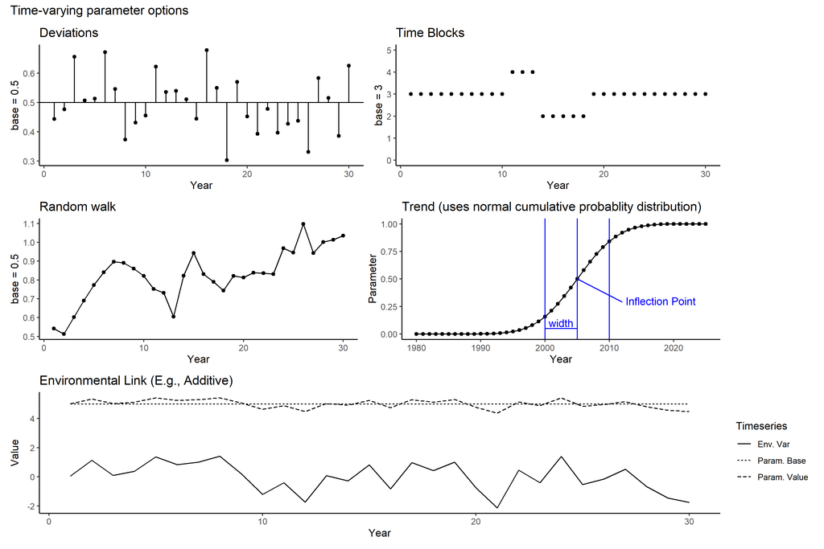

### 14.1.2 Specification of Time-Varying Parameters: Long Parameter Lines

Time-varying specifications for a parameter are invoked using elements 8 - 14 in the long parameter line setup. Each element and the options for selection related to time-varying parameters are as described below.

- Environmental or Density Dependent Link and variable (env_var&link; element 8)
  - The environmental or density dependent link and variable input is two inputs specified using a single three digit number. The hundreds place contains the option for the link function, while the tens and ones place is used to specify the environmental variable or derived quantity to which the parameter is linked. Note that environmental variables can only be included on an annual basis, so seasonal models would have the same effect applied to all seasons. If the environmental link and variable input is positive, then the parameter is linked to a variable specified in the data file environmental data; if it is negative, then the parameter is linked to a derived quantity. For example, env_var&link input 103 would use link type 1 and apply it to environmental data column 3, while the input -103 would use link type 1 and apply it to the “-3” column which is ln(relative summary biomass). The other options for both elements are enumerated below.
  - The link function options (hundreds place) for the env_var&link input are:
    - 1 = exponential scalar: $P_{y} = P_{base}e^{P_{t}E_{y}}$
    - 2 = linear offset: $P_{y} = P_{base} + P_{t}E_{y}$
    - 3 = Bounded replacement: $P_{y} = min(P_{base})+\frac{max(P_{base})-min(P_{base})}{1+e^{P_tE_y+ln((P_{base}-min(P_{base})+0.0000001)/(max(P_{base})-P_{base}+0.0000001))}}$
    - 4 = Logistic: $P_{y} = P_{base}\frac{2}{1+e^{-P_{t2}(E_{y}-P_{t1})}}$

    where:
    - $P_{y}$ = Parameter value in year $y$
    - $P_{base}$ = Base parameter value
    - $P_{t}$ = Link parameter value
    - $P_{t1}$ = First of 2 link parameters (offset)
    - $P_{t2}$ = Second of 2 link parameters (slope)
    - $E_{y}$ = Environmental index value or derived quantity value in year $y$
    - $min(P_{base})$ = the minimum parameter bound of base parameter
    - $max(P_{base})$ = the maximum parameter bound of base parameter
  - The variable options (tens and ones place, or $E_{y}$) for the env_var&link input are either 1) a positive integer from 1 to 99 referencing a time-series located in the environmental data section of the data file, or 2) a negative value of -1 to -4 where $E_y$ is one of the following model-derived quantities:
    - -1; for ln(relative spawning biomass)
    - -2; for recruitment deviation
    - -3; for ln(relative summary biomass) (e.g., current year summary biomass divided by the unfished summary biomass)
    - -4; for ln(relative summary numbers)
  - The four derived quantities are all calculated at the beginning of each year within the model, so they are available to use as the basis for time-varying parameter links without violating any order of operations rules.
- Deviation Link (element 9). A positive integer invokes parameter deviations, but otherwise should be left as 0. SS3 expects the estimated deviations to be normal in distribution and the deviation values are multiplied by the standard error parameter as they are used. This differs from recruitment deviations and from the approach in SS3 v.3.24. Link options for parameter deviations are:
  - 1 = multiplicative: $P_y = P_{base,y}e^{\text{dev}_y*\text{dev}_{se}}$,
  - 2 = additive: $P_y = P_{base,y} + \text{dev}_y*\text{dev}_{se}$,
  - 3 = random walk. Random walk options are implemented by using $\rho$ in the objective function. $P_y = P_{base,y} + \sum_{n=1}^{y} \text{dev}_n*\text{dev}_{se}$
  - 4 = mean reverting random walk with $\rho$.
    - $X_1 = \text{dev}_1*\text{dev}_{se}$
    - $P_1 = P_{base,y} + X_1$
    - $X_y = \rho*X_{y-1} + \text{dev}_y*\text{dev}_{se}$
    - $P_y = P_{base,y} + X_y$
  - 5 = mean reverting random walk with $\rho$ and a logit transformation to stay within the minimum and maximum parameter bounds (approach added in SS3 v.3.30.16)
    - $X_1 = \text{dev}_1*\text{dev}_{se}$
    - $R = P_{max} - P_{min}$
    - $Y_1 = ln(\frac{P_{base,y} - P_{min} + \text{nil}}{P_{max} - P_{base,y} + nil})$
    - $P_1 = P_{min} + \frac{R}{1 + e^{-Y_1 - X_1 }}$. For the first year.
    - $X_y = \rho*X_{y-1} + \text{dev}_y*\text{dev}_{se}$
    - $Y_y = ln(\frac{P_{base,y} - P_{min} + nil}{P_{max} + P_{base,y} + nil})$
    - $P_1 = P_{min} + \frac{R}{1 + e^{-Y_y - X_y }}$. For years after the first year.
  - 6 = mean reverting random walk with penalty to keep the root mean squared error (RMSE) near 1.0. Same as case 4, but with penalty applied.
  - The option of extending the final model year deviation value subsequent years (i.e., into the forecast period) was added in v. 3.30.13. This new option is specified by selecting the appropriate deviation link option and appending a 2 at the front (e.g, 25), which will use the final year deviation value for all forecast years.

  where:
  - $P_{y}$ = Parameter value in year $y$
  - $P_{base,y}$ = Base parameter value for year $y$
  - $\text{dev}_y$ = deviation in year $y$
  - $\text{dev}_{se}$ = standard error of the deviation
  - nil is a small value (e.g., 0.0000001)
- Deviation Minimum Year (element 10). Year deviations start for the parameter. This must be specified if using parameter deviations, but otherwise should be left as 0.
- Deviation Maximum Year (element 11). Year deviations end for parameter. This must be specified if using parameter deviations, but otherwise should be left as 0.
- Deviation Phase (element 12). The phase in which the deviations for the parameter should be estimated. This must be specified if using parameter deviations, but otherwise should be left as 0.
- Use Time Blocks or Trends (element 13). Time blocks and trends are both specified using this input. If neither are used, this should be left as 0. For trend options, the cumulative normal distribution function is used as the shape of the trend in all cases, but the parameterization differs. In general, the trend used is:
  $$P_y = P_{base} + P_{\text{offset}}\phi(\frac{y - P_{\text{infl}}}{P_{width}})$$
  where
  - $P_y$ is the final parameter value in year $y$
  - $P_{base}$ is the base parameter value
  - $P_{\text{offset}}$ is the parameter offset value
  - $\phi$ is the standard cumulative normal distribution function
  - $P_{\text{infl}}$ is the inflection year (i.e., the year in which half of the total change from the base parameter has occurred)
  - $P_{width}$ is the standard deviation.

  In all cases, 3 parameters are estimated and hence 3 short parameter lines are required. These parameter lines differ amongst the trend options.

  The input value options for element 13 are:
  - >0: time block index for parameter. See the time blocks section of the control file for more information on specifying time blocks.
  - -1: Trend Offset option. Three parameters are estimated: end trend value as a logistic offset (input as $ln(P_{\text{offset}})$), inflection year logistic offset (input as $ln(P_{\text{infl}})$, and width ($P_{width}$. Offset trend value is in natural log space. Inflection year is also in natural log space and offset from ln(0.5). Width is directly specified.
  - -2: Trend Direct input option. In this case, $P_{\text{offset}} = 1$. Three parameters are input via short parameter lines: end trend parameter value ($P_y$ where $y$ is the final year), inflection year ($P_{\text{infl}}$, and width ($P_{width}$).
  - -3: Trend Fractional option. In this case, $P_{\text{offset}} = 1$. Three parameters will be estimated: end trend parameter value as a fraction of base parameter maximum - minimum, inflection year as a fraction of end year - start year, and width ($P_{width}$). Width is directly input.
- Time Block Functional Form (element 14). Leave as 0, unless time blocks are used.
  - 0: multiplicative parameter ($P_{block} = P_{base}*e^{P_t}$)
  - 1: additive parameter ($P_{block} = P_{base} + P_t$)
  - 2: replace parameter ($P_{block} = P_t$)
  - 3: random walk across blocks ($P_{block} = P_{block,-1} + P_t$)

  where:
  - $P_{block}$ = Final parameter value in time block $block$
  - $P_{base}$ = Base parameter value
  - $P_{t}$ = Time-varying parameter value for a time block
  - $P_{block,-1}$ = Final parameter value in the previous time block

Code for the deviation link can be found in SS_timevaryparm.tpl, search for “SS_Label_Info_14.3.”

### 14.1.3 Specification of Time-Varying Parameters: Short Parameter Lines

If a time-varying specification set up in the long parameter lines for a particular section requires additional parameters, short parameter lines need to be created following the long parameter lines for the section (unless autogeneration is used, which creates short parameter lines in control.ss_new upon running the model). The number of parameter lines required depends on the time-varying parameter specification.

For example, if two parameters were specified to have environmental linkages in the MG parameter section, below the MG parameters would be two parameter lines (when not auto-generating these lines), which is an environmental linkage parameter for each time-varying base parameter:

|  |  |  | Prior | Prior | Prior |  |  |
| --- | --- | --- | --- | --- | --- | --- | --- |
| LO | HI | INIT | Value | SD | Type | Phase | Parameter Label |
|  |  |  | Prior | Prior | Prior |  |  |
| LO | HI | INIT | Value | SD | Type | Phase | Parameter Label |
| -99 | 99 | 1 | 0 | 0.01 | 0 | -1 | #Wtlen_1_Fem_ENV_add |
| -99 | 99 | 1 | 0 | 0.01 | 0 | -1 | #Wtlen_2_Fem_ENV_add |

In SS3 v.3.30, the time-varying input short parameter lines are organized such that all parameters that affect a base parameter are clustered together with time blocks (or trend) first, then environmental linkages, then parameter deviations. For example, if the mortality-growth (MG) base parameters 3 and 7 had time varying changes, the order would look like:

| MG base parameter 3 | Block parameter 3-1 |
| --- | --- |
|  | Block parameter 3-2 |
|  | Environmental link parameter 3-1 |
|  | Deviation se parameter 3 |
|  | Deviation $\rho$ parameter 3 |
| MG base parameter 7 | Block parameter 7-1 |
|  | Deviation se parameter 7 |
|  | Deviation $\rho$ parameter 7 |

The number of short parameter lines for each time-varying setup selected depends on the selection options. The autogeneration feature can be used to figure out which parameter lines are needed. The short parameter lines needed for different time-varying options are:

- Environmental Linkages: Requires 1 short parameter line ($P_{t}$), except for link option 4, which requires 2 short parameter lines ($P_{t1}$ and $P_{t2}$).
- Parameter deviations: Requires 2 short parameter lines, one for the standard error ($\text{dev}_{se}$), followed by one for $\rho$. Note that an input for $\rho$ is required but only used with random walk options. For the random walk options, $\rho$ can be set at 1 for a random walk with no drift or >1 for a random walk with drift.
- Time Blocks: One parameter for each time block ($P_{t}$) set up in the pattern.
- Trends: Requires 3 parameter lines. The interpretation of the parameters differs by the trend option selected, but in general they are a parameter for the final parameter value, a parameter for the inflection point year, and a parameter for the width (i.e., the standard deviation).

### 14.1.4 Example Time-varying Parameter Setups

The time-varying parameter options in Stock Synthesis are flexible. Below are some example setups that illustrate how the time-varying options could be used in a model, although there are many more possible setups.

#### 14.1.4.1 Environmental and density dependent linkages

- Suppose growth rate is found to be linked with an index of water temperature. The water temperature proxy could be input into the data file as environmental data. If it is input as index number 1, the growth parameter $K$ (if using a von Bertalanffy growth equation) could be linked to the water temperature proxy data by specifying the code “201” in the env_var&link function input. This would establish an offset link between the parameter and the temperature proxy. One additional parameter line is required after the “MG parameter” long parameter lines section.
- Suppose for a fishery, selectivity is thought to shift depending on population size. Smaller fish are selected when there are lower population numbers, while larger fish are selected when there are higher population numbers. The selectivity parameter could be made time-varying using the code “-104” in the env_var&link option, which assumes a exponential scalar link between the base selectivity parameter and the time varying parameter value. One additional parameter line is required at the end of the selectivity long parameter lines section.

#### 14.1.4.2 Parameter Deviations

- Suppose a selectivity parameter is thought to drift every year during 2000-2010. This could be represented using a random walk link option available within the parameter deviations options. To implement this, the user could input 3 into the “dev link” input on the long parameter line for the selectivity parameter, and then input values 2000 and 2010 for “dev min yr” and “dev max yr,” respectively. The dev phase could be set to 3. With this setup, 2 additional short parameter lines would be expected, one for the standard error and one for $\rho$. Both of these will be used since a random walk option is selected. To use a random walk without drift, $\rho$ is set at 1 with a negative phase.

#### 14.1.4.4 Trends

- Suppose natural mortality was thought to increase from 0.1 to 0.2 during 2000 to 2010. This could be input as a trend. First, the natural mortality parameter would be fixed at an initial value of 0.1. Then, a value of -2 could be input into the “use block” column of the natural mortality long parameter line to indicate that the direct input option for trends should be used. The long parameter line for M could look like:

  | LO | HI | INIT | <other entries> | PHASE | <other entries> | Use_Block | Block Fxn | Parameter Label |
  | --- | --- | --- | --- | --- | --- | --- | --- | --- |
  | 0 | 4 | 0.1 | ... | -1 | ... | -2 | 0 | #M |

- Three short parameter lines are then expected after the mortality-growth long parameter lines, one for the final value, one for the inflection year and one for the width. The final value could be fixed by using 0.2 as the final value on the short parameter line and a negative phase value. The inflection year could be fixed at 2005 by inputting 2005 for the inflection year in the short parameter line with a negative phase. Finally, the width value (i.e., standard deviation of the cumulative normal distribution) could be set at 3 years. The short parameter lines could look like:

  |  |  |  | Prior | Prior | Prior |  |  |
  | --- | --- | --- | --- | --- | --- | --- | --- |
  | LO | HI | INIT | Value | SD | Type | Phase | Parameter Label |
  |  |  |  | Prior | Prior | Prior |  |  |
  | LO | HI | INIT | Value | SD | Type | Phase | Parameter Label |
  | 0.001 | 4 | 0.2 | 0 | 0.01 | 0 | -1 | #M_TrendFinal |
  | 1999 | 2011 | 2005 | 0 | 0.01 | 0 | -1 | #M_TrendInfl |
  | -99 | 99 | 3 | 0 | 0.01 | 0 | -1 | #M_TrendWidth_yrs |

### 14.1.5 Time-Varying Growth Considerations

When time-varying growth is used, there are some additional considerations to be aware of:

- Growth in the forecast with time blocks: Growth deviations propagate into the forecast because growth is by cohort according to the current year’s growth parameters. The user can select which growth parameters get used during the forecast by setting the end year of the last block, if using time blocks. If the last block ends in the model’s end year, then the growth parameters in effect during the forecast will be the base parameters. By setting the end year of the last block to one year past the model end year (endyr), the model will continue the last block’s growth parameter levels throughout the forecast.
- The equilibrium benchmark quantities (MSY, F40%, etc.) previously used the model end year’s (endyr) body size-at-age, which is not in equilibrium. Through the forecast file, it is possible to specify a range of years over which to average the size-at-age used in the benchmark calculations. An option to create equilibrium growth from averaged growth parameters would be a more realistic option and is under consideration, but is not yet available.

### 14.1.6 Time-Varying Stock-Recruitment Considerations

- The $\sigma_R$ and autocorrelation parameters cannot be time-varying.
- The autocorrelation parameter cannot be estimated accurately within SS3 (Johnson et al. 2016), so external (i.e., external to SS3) estimation for selecting an autocorrelation value is currently recommended. The autocorrelation of the recruitment deviations appears in the report file, which can aid in selecting the autocorrelation value.
- The value of R0 and steepness in the initial year are used within virgin calculations and within the benchmarks for calculation of the denominator in depletion estimates. The average value of R0 and steepness in the range of years specified as the benchmark years inputs 9 and 10 (see the forecast file specifications) is used for MSY-type calculations.
- The spawner-recruit regime parameter is a modifier on R0. The regime shift parameter line allows for multi-year or environmentally driven deviations from R0 without changing R0 itself. The regime shift base parameter should have a base value of 0.0 and not be estimated (i.e., have a negative phase). Similar to the cohort-growth deviation, it serves simply as a base for adding time-varying adjustments.
- The same algebraic effect on the calculated recruitment can be achieved by different combinations of spawner-recruit parameter options (e.g., changing R0 directly instead of the regime shift parameter). It is recommended to use block, trend or environmental effects on R0 only for long-term effects, and use time-vary effects on the regime shift parameter for transitory but multi-year deviations from R0.
- If the R0 or steepness parameters are time-varying, then the model will use the current year’s parameters to calculate the expected value of recruits as a function of the spawning biomass, then applies the recruitment deviations. If the regime shift parameter is time-varying, then the model applies the change in the regime shift parameter **after** calculating the expected value of recruits as a function of spawning biomass.

### 14.1.7 Forecast Considerations with Time-Varying Parameters

Users should judiciously consider which parameter values are applied during forecast years. SS3 will default to use all base parameter values during the forecast period, but alternatively, which years of selectivity, relative F, and recruitment should be used during the forecast period by specifying in the forecast file.

Time-varying parameters can extend into the forecast period. For example, a parameter with a time block that stops at the model end year will revert to the base parameter value for the forecast, but when the block definition extends to include some or all forecast years, the last block will apply to the forecast. A good practice is to use 9999 as the terminal year for the last block to ensure including all forecast years. If a parameter has deviations and the deviations’ year range includes the forecast years, then the parameter will have process uncertainty in the forecast years and MCMC draws(if using) will include the variability.

## 14.2 Parameterizing the Two-Dimensional Autoregressive Selectivity

When the two-dimensional autoregressive selectivity feature is turned on for a fleet, the selectivity is calculated as a product of the assumed selectivity pattern and a non-parametric deviation term deviating from this assumed pattern:

$$\hat{S}_{a,t} = S_aexp^{\epsilon_{a,t}}$$

where $S_a$ is specified in the corresponding age/length selectivity types section and it can be either parametric (recommended) or non-parametric (including any of the existing selectivity options in SS3); $\epsilon_{a,t}$ is simulated as a two-dimensional first-order autoregressive (2D AR1) process:

$$vec(\epsilon) \sim MVN(\mathbf{0},\sigma_s^2\mathbf{R_{total}})$$

where $\epsilon$ is the two-dimensional deviation matrix and $\sigma_s^2\mathbf{R_{total}}$ is the covariance matrix for the 2D AR1 process. More specifically, $\sigma_s^2$ quantifies the variance in selectivity deviations and $\mathbf{R_{total}}$ is equal to the kronecker product ($\otimes$) of the two correlation matrices for the among-age and among-year AR1 processes:

$$\mathbf{R_{total}}=\mathbf{R}\otimes\mathbf{\tilde{R}}$$

$$\mathbf{R}_{a,\tilde{a}}=\rho_a^{|a-\tilde{a}|}$$

$$\mathbf{\tilde{R}}_{t,\tilde{t}}=\rho_t^{|t-\tilde{t}|}$$

where $\rho_a$ and $\rho_t$ are the among age and among year AR1 coefficients, respectively. When both of them are zero, $\mathbf{R}$ and $\mathbf{\tilde{R}}$ are two identity matrices and their Kronecker product, $\mathbf{R_{total}}$, is also an identity matrix. In this case selectivity deviations are essentially identical and mutually independent:

$$\epsilon_{a,t}\sim N(0,\sigma_s^2)$$

#### 14.2.0.1 Using the Two-Dimensional Autoregressive Selectivity

Note, Xu et al. (2019) has additional information on tuning the 2D AR selectivity parameters. First, fix the two AR1 coefficients ($\rho_a$ and $\rho_t$) at 0 and tune $\sigma_s$ iteratively to match the relationship:

$$\sigma_s^2=SD(\epsilon)^2+\frac{1}{(a_{max}-a_{min}+1)(t_{max}-t_{min}+1)}\sum_{a=a_{min}}^{a_{max}}\sum_{t=t_{min}}^{t_{max}}SE(\epsilon_{a,t})^2$$

The minimal and maximal ages/lengths and years for the 2D AR1 process can be freely specified by users in the control file. However, we recommend specifying the minimal and maximal ages and years to cover the relatively “data-rich” age/length and year ranges only. Particularly we introduce:

$$b=1-\frac{\frac{1}{(a_{max}-a_{min}+1)(t_{max}-t{min}+1)}\sum_{a=a_{min}}^{a_{max}}\sum_{t=t_{min}}^{t_{max}}SE(\epsilon_{a,t})^2}{\sigma_s^2}$$

as a measure of how rich the composition data is regarding estimating selectivity deviations. We also recommend using the Dirichlet-Multinomial method to “weight” the corresponding composition data while $\sigma_s$ is interactively tuned in this step.

Second, fix $\sigma_s$ at the value iteratively tuned in the previous step and estimate $\epsilon_{a,t}$. Plot both Pearson residuals and $\epsilon_{a,t}$ out on the age-year surface to check their 2D dimensions. If their distributions seems to be not random but rather be autocorrelated (deviation estimates have the same sign several ages and/or years in a row), users should consider estimating and then including the autocorrelations in $\epsilon_{a,t}$.

Third, extract the estimated selectivity deviation samples from the previous step for estimating $\rho_a$ and $\rho_t$ externally by fitting the samples to a stand-alone model written in Template-Model Builder (TMB). In this model, both $\rho_a$ and $\rho_t$ are bounded between 0 and 1 via applying a logic transformation. If at least one of the two AR1 coefficients are notably different from 0, the model should be run one more time by fixing the two AR1 coefficients at their values externally estimated from deviation samples. The Pearson residuals and $\epsilon_{a,t}$ from this run are expected to distribute more randomly as the autocorrelations in selectivity deviations can be at least partially included in the 2D AR1 process.

## 14.3 Continuous seasonal recruitment

Setting up a seasonal model such that recruitment can occur with similar and independent probability in any season of any year is awkward in SS3. Instead, SS3 can be set up so that each quarter appears as a year (i.e., a seasons as years model). All the data and parameters are set up to treat quarters as if they were years. Note that setting up a seasons as years model also requires that all rate parameters be re-scaled to correctly account for the quarters being treated as years.

Other adjustments to make when using seasons as years include:

- Re-index all “year seas” inputs to be in terms of quarter-year because all are now season 1; increase end year (endyr) value in sync with this.
- Increase max age because age is now in quarters.
- In the age error definitions, increase the number of entries to reflect that age is now in quarters.
- In the age error definitions, recode so that each quarter-age gets assigned to the correct age bin. This is because the age data are still in terms of age bins; i.e., the first 4 entries for quarter-ages 1 through 4 will all be assigned to age bin 1.5; the next four to age bin 2.5; you cannot accomplish the same result by editing the age bin values because the standard deviation of ageing error is in terms of age bin.
- In the control file, multiply the natural mortality age breakpoints and growth Amin and Amax values by 1/season duration.
- Decrease the R0 parameter starting value because it is now the average number of recruitments per quarter year.
- Edit the recruitment deviation (rec_dev) start and end years to be in terms of quarter year.
- Edit any age selectivity parameters that refer to age, because they are now in terms of quarter age.
- If there needs to be some degree of seasonality to a parameter, then you could create a cyclic pattern in the environmental input and make the parameter a function of this cyclic pattern.

# 15 Detailed Information on Stock Synthesis Processes

The processes and calculations within SS3 can be complex and not transparent based on the model input files. Here, additional information on processes within SS3 is provided.

## 15.1 Jitter

The jitter function has been updated with SS3.30. The following steps are now performed to determine the jittered starting parameter values (illustrated in Figure 2):

1. A normal distribution is calculated such that the pr(P<sub>MIN</sub>) = 0.1% and the pr(P<sub>MAX</sub>) = 99.9%.
2. A jitter shift value, termed “*K*,” is calculated from the distribution equal to pr(P<sub>CURRENT</sub>).
3. A random value is drawn, “*J*,” from the range of *K*-jitter to *K*+jitter.
4. Any value which falls outside the 0-1 range (in the cumulative normal space) is mapped back from the bound to a point one-tenth of the way from the bound to the initial value.
5. *J* is a new cumulative normal probability value.
6. Calculate a new parameter value, P<sub>JITTERED</sub>, such that pr(P<sub>JITTERED</sub>) = *J*.

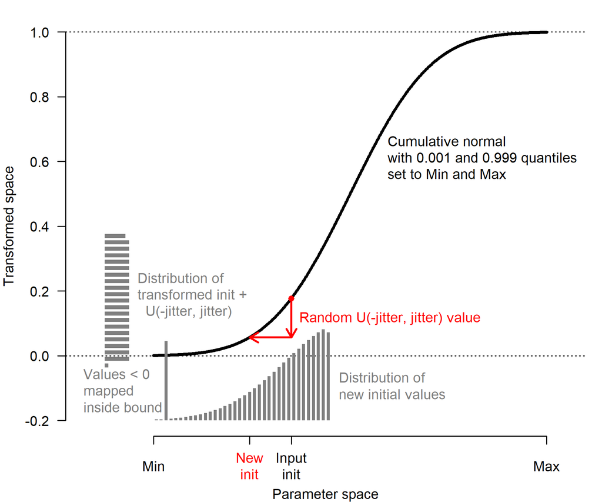

In SS3, the jitter fraction defines a uniform distribution in cumulative normal space +/- the jitter fraction from the initial value (in cumulative normal space). The normal distribution for each parameter, for this purpose, is defined such that the minimum bound is at 0.001, and the maximum at 0.999 of the cumulative distribution. If the jitter faction and original initial value are such that a portion of the uniform distribution goes beyond 0.001 or 0.999 of the cumulative normal, the new value is set to one-tenth of the way from the bound to the original initial value.

Therefore sigma = (max-min) / 6.18. For parameters that are on the log-scale, sigma may be the correct measure of variation for jitters, for real-space parameters, CV (= sigma/original initial value) may be a better measure.

If the original initial value is at or near the middle of the min-max range, then for each 0.1 of jitter, the range of jitters extends about 0.25 sigmas to either side of the original value (though as the total jitter increases the relationship varies more than this), and the average absolute jitter is about half of that. For values far from the middle of the min-max range, the resulting jitter is skewed in parameter space, and may hit the bound, invoking the resetting mentioned above.

To evaluate the jittering, the bounds, and the original initial values, a jitter_info table is available from r4ss, including sigma, CV and InitLocation columns (the latter referring to location within the cumulative normal - too close to 0 or 1 indicates a potential issue).

Note: parameters with min $\leq$ -99 or max $\geq$ 999 are not jittered to avoid unreasonable values (a warning is produced to indicate this).

## 15.2 Parameter Priors

Priors on parameters fulfill two roles in SS3. First, for parameters provided with an informative prior, SS3 is receiving additional information about the true value of the parameter. This information works with the information in the data through the overall log likelihood function to arrive at the final parameter estimate. Second, diffuse priors provide only weak information about the value of a prior and serve to manage model performance during execution. For example, some selectivity parameters may become unimportant depending upon the values of other parameters of that selectivity function. In the double normal selectivity function, the parameters controlling the width of the peak and the slope of the descending side become redundant if the parameter controlling the final selectivity moves to a value indicating asymptotic selectivity. The width and slope parameters would no longer have any effect on the log likelihood, so they would have no gradient in the log likelihood and would drift aimlessly. A diffuse prior would then steer them towards a central value and avoid them crashing into the bounds. Another benefit of diffuse priors is the control of parameters that are given unnaturally wide bounds. When a parameter is given too broad of a bound, then early in a model run it could drift into this tail and potentially get into a situation where the gradient with respect that parameter approaches zero even though it is not at its global best value. Here the diffuse prior helps move the parameter back towards the middle of its range where it presumably will be more influential and estimable.

The options for parameter priors are described as a function of $Pval$, the value of the parameter for which a prior is being calculated, as well as the parameter bounds in the case of the beta distribution ($Pmax$ and $Pmin$), and the input values for $Prior$ and $Pr\_SD$, which in some cases are the mean and standard deviation, but interpretation depends on the prior type. The Prior Likelihoods below represent the negative log likelihood in all cases.

#### 15.2.0.1 Prior Types

Note that the numbering in SS3 v.3.30 is different from that used in SS3 v.3.24 (where confusingly -1 indicated no prior and 0 indicated a normal prior). The calculation of the negative log likelihood is provided below for each prior types, as a function of the following inputs:

| $P_\text{init}$ | The value of the parameter for which a prior is being calculated where init can either be |
| --- | --- |
|  | the initial un-estimated value or the estimated value (3rd column in control or |
|  | control.ss_new file) |
| $P_\text{LB}$ | The lower bound of the parameter (1st column in control file) |
| $P_\text{UB}$ | The upper bound of the parameter (2nd column in control file) |
| $P_\text{PR}$ | The input value for the prior input (4th column in control file) |
| $P_\text{PRSD}$ | The standard deviation input value for the prior (5th column in control file) |

- **Prior Type = 0 = No prior applied**  
  In a Bayesian context this is equivalent to a uniform prior between the parameter bounds.
- **Prior Type = 1 = Symmetric beta prior**
  The symmetric beta is scaled between parameter bounds, imposing a larger penalty near the bounds. Prior standard deviation of 0.05 is very diffuse and a value of 5.0 provides a smooth U-shaped prior. The prior input is ignored for this prior type.
  $$\mu = -P_\text{PRSD} \cdot ln\left(\frac{P_\text{UB}+P_\text{LB}}{2} - P_\text{LB} \right) - P_\text{PRSD} \cdot ln(0.5)$$

  $$\begin{split} \text{Prior Likelihood} = &-\mu -P_\text{PRSD} \cdot ln\left(P_\text{init}-P_\text{LB}+0.0001\right) - \\ & P_\text{PRSD} \cdot ln\left(1-\frac{P_\text{init}-P_\text{LB}-0.0001}{P_\text{UB}-P_\text{LB}}\right) \end{split}$$

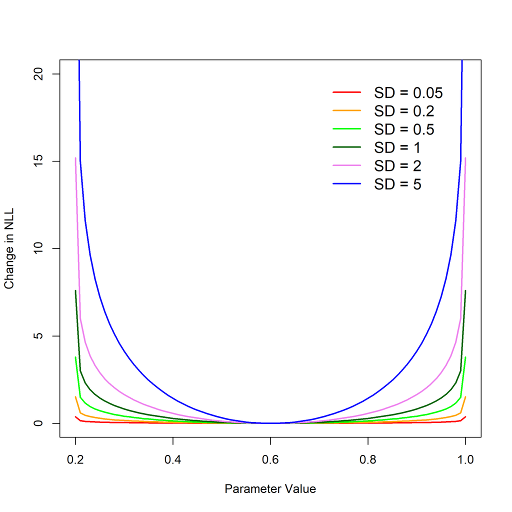

- **Prior Type = 2 = Beta prior**
  The definition of $\mu$ is consistent with CASAL’s formulation with the $\beta_\text{PR}$ and $\alpha_\text{PR}$ corresponding to the $m$ and $n$ parameters.
  $$\mu = \frac{P_\text{PR}-P_\text{LB}}{P_\text{UB}-P_\text{LB}}$$
  $$\tau = \frac{(P_\text{PR}-P_\text{LB})(P_\text{UB}-P_\text{PR})}{P_\text{PRSD}^2}-1$$
  $$\beta_\text{PR} = \tau \cdot \mu$$
  $$\alpha_\text{PR} = \tau (1-\mu)$$

  $$\begin{split} \text{Prior Likelihood} = &(1 - \beta_\text{PR}) \cdot ln(0.0001 + P_\text{init} - P_\text{LB}) + \\ &(1 - \alpha_\text{PR}) \cdot ln(0.0001 + P_\text{UB} - P_\text{init}) - \\ &(1 - \beta_\text{PR}) \cdot ln(0.0001 + P_\text{PR} - P_\text{LB}) - \\ &(1 - \alpha_\text{PR}) \cdot ln(0.0001 + P_\text{UB} - P_\text{PR}) \end{split}$$
- **Prior Type 3 = Lognormal prior**
  Note that this is undefined for $p <= 0$ so the lower bound on the parameter must be > 0. The prior value is input into the parameter line in natural log space while the initial parameter value is defined in normal space (e.g., init = 0.20, prior = -1.609438).
  $$\text{Prior Likelihood} = \frac{1}{2} \left(\frac{ln(P_\text{init})-P_\text{PR}}{P_\text{PRSD}}\right)^2$$
- **Prior Type 4 = Lognormal prior with bias correction**
  This option allows the prior mean value to be entered as the ln(mean). Note that this is undefined for $p <= 0$ so the lower bound on the parameter must be > 0.
  $$\text{Prior Likelihood} = \frac{1}{2} \left(\frac{ln(P_\text{init})-P_\text{PR} + \frac{1}{2}{P_\text{PRSD}}^2}{P_\text{PRSD}}\right)^2$$
- **Prior Type 5 = Gamma prior**
  The lower bound should be 0 or greater.
  $$\text{scale} = \frac{{P_\text{PRSD}}^2}{P_\text{PR}}$$
  $$\text{shape} = \frac{P_\text{PR}}{\text{scale}}$$
  $$\text{Prior Likelihood} = -\text{shape} \cdot ln(\text{scale}) - ln\big(\Gamma(\text{shape})\big) + (\text{shape} - 1) \cdot ln(P_\text{init}) - \frac{P_\text{init}}{\text{scale}}$$
- **Prior Type 6 = Normal prior**
  Note that this function is independent of the parameter bounds.
  $$\text{Prior Likelihood} = \frac{1}{2} \left(\frac{P_\text{init} - P_\text{PR}}{P_\text{PRSD}}\right)^2$$

## 15.3 Forecast Module: Benchmark and Forecasting Calculations

SS3 v.3.20 introduced substantial upgrades to the benchmark and forecast module. The general intent was to make the forecast outputs more consistent with the requirement to set catch limits that have a known probability of exceeding the overfishing limit. In addition, this upgrade addressed several inadequacies with the previous module, including:

- The average selectivity and relative F was the same for the benchmark and the forecast calculations;
- The biology-at-age in endyr+1 was used as the biology for the benchmark, but biology-at-age propagated forward in the forecast if there was time-varying growth;
- The forecast module had a inefficient approach to calculation of overfishing limit (OFL) conditioned on previously catching ABC;
- The forecast module implementation of catch caps was incomplete and applied some caps on a seasonally, rather than the more logical annual basis;
- The Fmult scalar for fishing intensity presented a confusing concept for many users;
- No provision for specification of catch allocation among fleets;
- The forecast allowed for a blend of fixed input catches and catches calculated from target F; this is not optimal for calculation of the variance of F conditioned on a catch policy that sets annual catch limits (ACLs).

The V3.20 module addressed these issues by:

- Providing for unique specification of a range of years from which to calculate average selectivity for benchmark, average selectivity for forecast, relative F for benchmark, and relative F for forecast;
- Create a new specification for the range of years over which to average size-at-age and fecundity-at-age for the benchmark calculation. In a setup with time-varying growth, it may make sense to do this over the entire range of years in the time series. Note that some additional quantities still use their endyr values, notably the migration rates and the allocation of recruitments among areas. This will be addressed shortly;
- Create a multiple pass approach that rectifies the OFL calculation;
- Improve the specification of catch caps and implement specification of catch allocations so that there can be an annual cap for each fleet, an annual cap for each area, and an annual allocation among groups of fleets (e.g., all recreational fleets vs. all commercial fleets);
- Introduce capability to have implementation error in the forecast catch (single value applied to all fleets in all seasons of the year).

#### 15.3.0.1 Multiple Pass Forecast

The most complicated aspect of the changes is with regard to the multiple pass aspect of the forecast. This multiple pass approach is needed to calculate both OFL and ABC in a single model run. More importantly, the multiple passes are needed in order to mimic the actual sequence of assessment-management action - catch over a multi-year period. The first pass calculates OFL based on catching OFL each year, so presents the absolute maximum upper limit to catches. The second pass forecasts a catch based on a harvest policy, then applies catch caps and allocations, then updates the F’s to match these catches. In the third pass, stochastic recruitment and catch implementation error are implemented and SS3 calculates the F that would be needed in order to catch the adjusted catch amount previously calculated in the second pass. With this approach, SS3 is able to produce improved estimates of the probability that F would exceed the overfishing F. In effect it is the complement of the P* approach. Rather than the P* approach that calculates the stream of annual catches that would have an annual probability of F>Flimit, SS3 calculates the expected time series of P* that would result from a specified harvest policy implemented as a buffer between Ftarget and Flimit.

#### 15.3.0.2 Example Effects on Correlations

An example that illustrates the above process was conducted. The situation was a low M, late-maturing species, so changes are not dramatic. The example conducted a 10 year forecast and examined correlations with derived quantities in the last year of the forecast. This was done once with the full set of 3 passes as described above, and again with only 2 passes and stochastic recruitment occurring in pass 2, rather than 3. This alternative setup is more similar to forecasts done using previous model versions.

[output not shown]

Correlation A1 shows this turning into a negative correlation. This is because the future catches are first calculated from equilibrium recruitment, then when random recruitments are implemented, a positive recruitment deviation will cause a negative deviation in the F needed to catch that now “fixed” amount of future catch.

Correlations B1 and B2 are in terms of absolute recruitment, not recruitment deviation. Now overall model conditions that cause a higher absolute recruitment level will also result in a higher forecast level. No surprise there, and the correlation is stronger when variance is based on catch is calculated from F (B2).

Correlation C2 shows a positive correlation between recruitment deviation in 2002 and forecast catch in 2011. However, correlation C1 is 0.0 because the forecast catch in 2011 is set based on equilibrium recruitment and is not influenced by the recruitment deviations.

#### 15.3.0.3 Future Work

- More testing with high M, rapid turnover conditions
- Testing without inflection in control rule
- Consider separating implementation error into a pass #4 so results will more clearly show effect of assessment uncertainty separate from implementation uncertainty
- Consider adding a random “assessment” error which essentially is a random variable that scales population abundance before passing into the forecast stage. Complication is figuring out how to link it to the correlated error in the benchmark quantities
- Because all of these calculations occur only in the standard deviation phase (sdphase) or the MCMC evaluation (mceval) phase, it would be feasible for mceval calls to add an additional pass that is implemented many times and in which random forecast recruitment draws are made.
- Factors like selectivity and fleet relative F levels are calculated as an average of these values during the time series. This is internally consistent if these factors do not vary during the time series (although clearly this is a stiff model that will underestimate process variance. However, if these factors do vary over time, then the average used for the forecast will under-represent the variance. A better approach would be to set up the parameters of selectivity as a random process that extends throughout the forecast period, and to update estimated selectivity in each year of the forecast based upon the random realization of these parameters.

## 15.4 Fishing Mortality in Stock Synthesis

The implementation and reporting of fishing mortality rate, $F$, in SS3 has some aspects that can be confusing. This description provides an overview of the ways in which $F$ is calculated, used, and reported.

#### 15.4.0.1 Rationale

Fishery management systems expect to have a measure of annual fishing mortality that describes the intensity of the fishery such that an optimal level of $F$ can be articulated and accountability measures can be invoked if $F$ is too high, e.g., overfishing. This concept is simple and straightforward if the model is a simple biomass dynamics such that a single annual $F$ value operates on the entirety of a non-age structured population. It also is simple for age-structured models that have a single fishing fleet and knife-edge selectivity beginning at some specified age.

The simplicity of $F$ disappears quickly as models invoke a variety of realistic complexities such as: allowing the $F$ to differ among ages or to be based on size; using a collection of fleets with different $F$ levels and different age patterns for $F$; spreading the population across areas and allowing different fleets with different $F$ among the areas. An unambiguous measure of annual fishing intensity that represents the cumulative effect of all that complexity has not been defined. This problem has not been solved with SS3, but some logical alternatives have been made available.

#### 15.4.0.2 Nomenclature

The nomenclature below ignores sex, morphs and areas for simplicity. The quantities associated with $F$ calculations are defined as:

$f$ is fleet.

$t$ is a time step; continuous across years $y$ and seasons $s$; equivalent to year if only 1 season.

$a$ is age.

$C_{t,f}$ is fleet-specific catch in a time step.

$B_{t,f}$ is fleet specific available biomass, e.g., total biomass filtered by fleet-specific age selectivity, $s_{t,f,a}$.

$s_{t,f,a}$ is age-specific selectivity for a fleet. If selectivity is length-specific, then age-specific selectivity is calculated as the dot product across length bins of length selectivity and the normal (or lognormal) distribution of length-at-age. If selectivity is both length- and age-based, which is an entirely normal concept in SS3, then age selectivity due to length selectivity is calculated first, then multiplied by the direct age selectivity. This compound age selectivity is used in the mortality calculations and is reported as asel2 in report file. See appendix to Methot and Wetzel (2013) for more detail on this.

$F_{t,f}'$ is the apical fishing mortality for a fleet. This means that it is the rate for the age that has selectivity equal to 1.0. If your model is using $F'$s as parameters, then the parameter values are for $F'$.

$F_{t,f,a}$ is age and fleet-specific fishing mortality rate equal to $F_{t,f}' * s_{t,f,a}$. Note that it is possible for no age to have a selectivity equal to 1.0. In this case, $F'$ is still the rate for the hypothetical age that has selectivity equal to 1.0. The reported $F'$ values are not rescaled to be an $F$ for the age with peak selectivity. Users need to take this into account if they are comparing reported $F'$ values to reported vector of $F_{t,f,a}$ values.

$\text{ann}F_y$ is a measure of the total fishing intensity for a year, based on one of several user-specified options (see below).

$F\text{std}_y$ is a standardized measure of the total fishing intensity for a year and is reported in the derived quantities, so variance is calculated for this quantity. See below for how it relates to $annF$.

Terminology and reporting of $\text{ann}F$ and $F\text{std}$ has been slightly revised for clarity in 3.30.15.00 and the description here follows the new conventions.

#### 15.4.0.3 $F$ Calculation

SS3 allows for three approaches to estimate the $F'$ that will match the input values for retained catch. Note that SS3 is calculating the $F'$ to match the retained catch conditional on the fraction of total catch that is retained, e.g., the total catch is partitioned into retained and discarded portions.

1. Pope’s method decays the numbers-at-age to the middle of the season, calculates a harvest rate for each fleet, $H_{t,f}$, that is the ratio of $C_{t,f}$ to $B_{t,f}$, then decays the survivors to the end of the season. the total mortality, $Z_{t,a}$, from the ratio of survivors to initial numbers, is then calculated. The $Z$ is subsequently used for in-season interpolation to get expected values for observations.
2. $F$ as parameters uses the standard Baranov catch equation and lets ADMB find the $F'$ parameter values that produce the lowest negative log-likelihood, which includes fit to the input catch data. $F$ as parameters method tends to work better than Pope’s or hybrid in high $F$ situations because it allows for some lack of fit to catch levels in early iterations and can later improve this fit as it closes in on the best solution.
3. Hybrid $F$ starts by calculating a harvest rate, $H$, using Pope’s, then converts these $H$ values, which have units of fractional harvest rate, into an approximate of $F'$ in exponential units, tuning these $F'$ values over a few iterations to get a better match to each fleet’s catch.

Items to note:

- SS3 includes a permutation on the $F$ as parameters method. In the first few phases, SS3 uses hybrid, then between phases it converts these directly calculated $F'$ values into parameters and proceeds in subsequent phases and MCMC to use the parameter approach. This variation on the parameter method is the recommend approach in high $F$ situations.
- With Pope’s method, the $H$ values are fraction caught, so duration of the season does not matter. Parameter and hybrid treat $F'$ identically and multiply the $F'$ values by season duration (which has units of fraction of a year) as it is used. Each of the $F$ methods ends up with a $Z_{t,f}$ that is used for in-season interpolation.

#### 15.4.0.4 Relative $F$ and $F$mult

The $F'$ is fleet-specific, so it is useful to have a concept of relative $F$, $\text{rel}F_f$, among fleets. In SS3, $\text{rel}F_f= F_{t,f}'/\sum_{f}^{}F_{t,f}'$ for a single time period $t$. In the benchmark and forecast routines, SS3 can calculate $\text{rel}F_f$ using $F_{t,f}'$ over a range of years, or the user can input custom $\text{rel}F$ values for benchmark and forecast in the forecast.ss file. Note that in a multi-season model setup, $\text{rel}F_f$ is implemented as $\text{rel}F_{s,f}$ where $s$ is the season. These get multiplied by season duration as they are used.

In the benchmark section of the code, SS3 searches for an $F$mult to achieve various management reference points (often referred to as benchmarks). In this search, SS3 calculates a benchmark $F$ as $F_{ben,f}' = F\text{mult} * \text{rel}F_f$, then calculates equilibrium yield and spawning biomass per recruit (SPR). SS3 searches for the $F$mult that satisfies the search conditions, first for user-specified SPR, then for user-specified spawning biomass at a management target (B<sub>TGT</sub> or $F_{0.1}$), then for MSY. The resultant benchmark quantities are reported in the derived quantities, but $F$mult and $F_{ben,f}'$ are only reported in the Forecast_report.sso file. SS3 stores the benchmark $F$mult values so that user can invoke them for the forecast.

#### 15.4.0.5 Annual $F$

The $\text{ann}F$ is a single annual value across all fleets and areas according to F_report_units, which is specified by users in the starter file. If there are many fleets, across several areas and with very different selectivity patterns, $\text{ann}F$ can have a complicated relationship to apical $F$. The F_report_units specification in the starter.ss file, see example line below, allows user to calculate it using $F'$ directly, use exploitation rate, or be derived from $Z$-at-age.

Example $F$ reporting unit specification in the starter.ss file:

| 5 | # F_report_units: |
| --- | --- |
|  | 0 = skip; |
|  | 1 = exploitation(Bio); |
|  | 2 = exploitation(Num); |
|  | 3 = sum(Frates); |
|  | 4 = true F for range of ages; |
|  | 5 = unweighted avg. F for range of ages. |
| 3 7 | # min and max age over which average F will be calculated |

For options 4 and 5 of F_report_units, the $F$ is calculated as $Z-M$ where $Z$ is calculated as $ln(N_{t+1,a+1}/N_{t,a})$, thus $Z$ subsumes the effect of $F$.

The ann$F$ is calculated for each year of the estimated time series and of the forecast. Additionally, an ann$F$ is calculated in the benchmark calculations to provide equilibrium values that have the same units as ann$F$ from the time series. In versions previous to 3.30.15, it was labeled inaccurately as $F$std in the output, not ann$F$. For example, in the Management Quantities section of derived quantities prior to 3.30.15, there is a quantity labeled Fstd_Btgt. This is more accurately labeled as the annual $F$ associated with the biomass target, ann_F_Btgt, in 3.30.15.

#### 15.4.0.6 $F$std

$F$std is a single annual value based on ann$F$ and the relationship to ann$F$ is specified by F_report_basis in the starter.ss file. The benchmark ann$F$ may be used to rescale the time series of ann$F$s to become a time series of standardized values representing the intensity of fishing, $F$std. The report basis is selected in the starter file as:

| 0 | # F_report_basis: |
| --- | --- |
|  | 0 = raw F report; |
|  | 1 = F / F<sub>SPR</sub>; |
|  | 2 = F / F<sub>MSY</sub>; |
|  | 3 = F / F<sub>BTGT</sub>. |

For example, if user selects option 1, $F$ / $F_\text{SPR}$, the time series of ann$F$ will be divided by each value by the ann$F$ calculated in benchmark.

#### 15.4.0.7 Units for Stock Synthesis inputs related to $F$

Below is a list of items to consider in terms of units for $F$ in SS3:

- If F_ballpark is specified in the control.ss file, its units are the same as ann$F$, so is not fleet-specific.
- $F$ as parameter values has units of fleet-specific apical $F'$.
- In the forecast.ss file there is an option to input a vector of rel$F$ values. These are dimensionless and will be rescaled to sum to 1.0.
- In the forecast.ss file there is an option to specify an $F$ scalar for the forecast. The units of $F$ scalar are the same as the $F$mult values calculated in benchmark. There are a full set of options for forecast $F$ scalar that can be selected in the forecast file If the forecast $F$ scalar is set as $F_\text{SPR}$, then SS3 will use SPR_Fmult calculated in benchmark and reported in Forecast-report.sso. If user selects the option to input an annual $F$ scalar, option 5, then the value is input on a following line. Whichever method the user selects for forecast $F$ scalar ($F$mult), SS3 will start the forecast by creating a fleet-specific vector of apical $F$ values from $F$mult*rel$F_f$.
- Also in the forecast.ss file, the last section of inputs allows for input of time and fleet specific apical $F_{t,f}'$ values that override the basic forecast $F$ specification described above.

# 16 Guidance on Population Dynamics Modeling

Numerous assessment related topics have arisen among users. A collection of general information on population dynamics modeling is provided here. This information is relative to both users of SS3 and users of other stock assessment modeling platforms.

## 16.1 Data Weighting

In 2015 there was a CAPAM workshop dedicated to data weighting. Description of the workshop can be found on the [CAPAM](http://capamresearch.org/data-weighting/workshop) website. The presentations from the workshop are available through that website and many of them were included in a special issue of [Fisheries Research](https://sciencedirect.com/journal/fisheries-research/vol/192).

Currently, there are three main methods for weighting length and data applied for U.S. West Coast assessments using Stock Synthesis.

1. **McAllister - Ianelli**: Effective sample size is calculated from fit of observed to expected length or age compositions. Tuning algorithm is intended to make the arithmetic mean of the input sample size equal to the harmonic mean of the effective sample size (McAllister and Ianelli 1997).
2. **Francis**: Based on variability in the observed mean length or age by year, where the sample sizes are adjusted such that the fit of the expected mean length or age should fit within the uncertainty intervals at a rate which is consistent with variability expected based on the adjusted sample sizes (Method “TA1.8”) (Francis and Hilborn 2011)
3. **Dirichlet-Multinomial**: A new likelihood (as opposed to the standard multinomial) which includes an estimable parameter (theta) which scales the input sample size. In this case, the term “Effective sample size” has a different interpretation than in the McAllister-Ianelli approach (Thorson et al. 2017).

#### 16.1.0.1 Applying the methods

#### 16.1.0.2 McAllister-Ianelli

The “Length_Comp_Fit_Summary” and “Age_Comp_Fit_Summary” sections in the Report file include information on the harmonic mean of the effective sample size and arithmetic mean of the input sample size used in this tuning method. In the r4ss package, these tables are returned by the `SS_output` function as `$Length_comp_Eff_N_tuning_check` and `$Age_comp_Eff_N_tuning_check`.

A convenient way to process these values into the format required by the control file is to use the function:

`SS_tune_comps(replist, option = “MI”)`

where the input “replist” is the object created by `SS_output`. This function will return a table and also write a matching file called “suggested_tuning.ss” to the directory where the model was run.

For version 3.30 models, the table created by `SS_tune_comps` can be pasted into the bottom of the control file in the section labeled “Input variance adjustments,” followed by the terminator line which indicates the end of the section.

Also see the help page for the r4ss function `SS_varadjust` which can be used to automatically write a new control file if you want to streamline the process of applying multiple iterations of this tuning method.

If the tuning has been implemented, the green lines in the figure below would approximately intersect at a point which is on the black 1-to-1 diagonal line in this figure created by the r4ss function `SS_plots`.

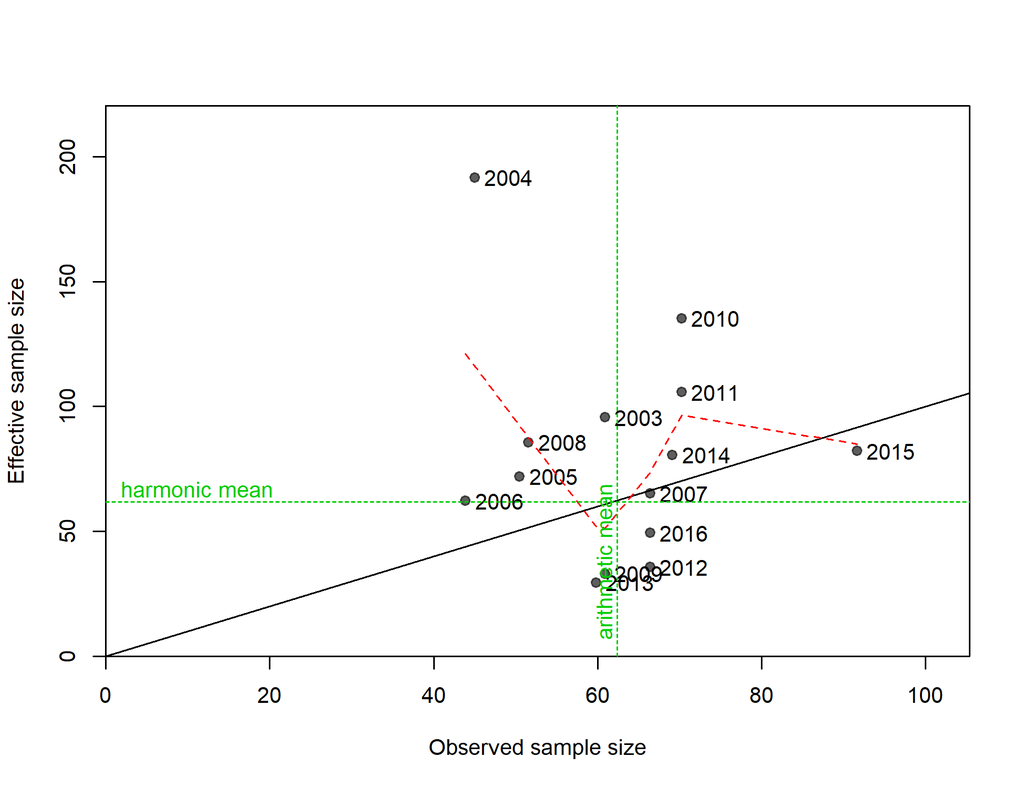

There are a couple of challenges posed by the McAllister-Ianelli data-weighting approach:

1. Subjective choice of how many iterations to take to achieve adequate convergence. Often just one iteration is applied.
2. Takes time to implement so tuning is rarely repeated during retrospective or sensitivity analyses.

#### 16.1.0.3 Francis

Implementation: recommended adjustments are calculated by the r4ss functions `SSMethod.TA1.8` and `SSMethod.Cond.TA1.8`. These functions are rarely used alone but are called by the `SS_plots` function when making plots like the one below. For version 3.30 models, the simplest way to get the adjustments in the format required by the control file is to use the `SS_tune_comps` function (described above under the McAllister-Ianelli method), but with a different option specified:

`SS_tune_comps(replist, option = “Francis”)`

The figure below shows the estimated 95% intervals around the observed mean length by year based on the input sample size (thick lines) and the increase in that uncertainty which would occur if the sample sizes were adjusted according to the proposed multiplier.

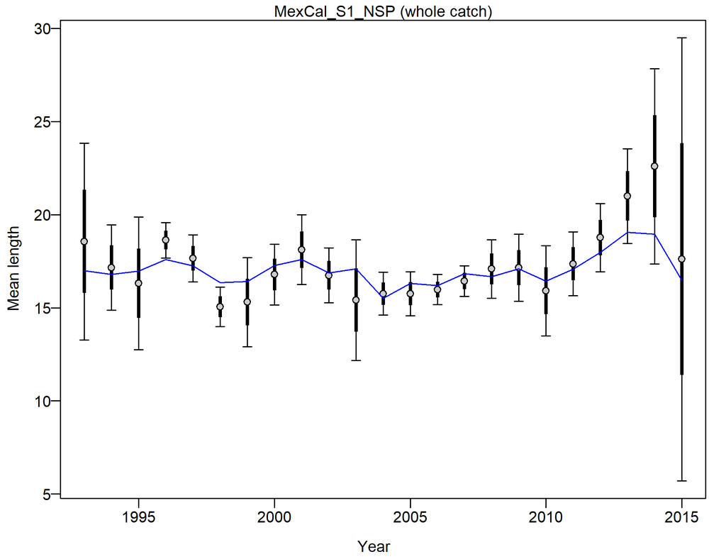

There are a several of challenges posed by the Francis data-weighting approach:

1. Subjective choice of how many iterations to take to achieve adequate convergence. Often just one iteration is applied.
2. Takes time to implement so tuning is rarely repeated during retrospective or sensitivity analyses.
3. Recommended adjustment can be sensitive to outliers (remove a few years of anomalous composition data can lead to large change in recommended adjustment).

#### 16.1.0.4 Dirichlet-multinomial

The Dirichlet-Multinomial should only be used when there is a substantive basis for setting an approximate value for input sample size. This is important because:

- The input-sample-size provided by the user is an upper bound on weighting for those data, such that a dummy value of 1 will cause those data to never be assigned a weight .
- Changes in input sample size are not quite proportionally offset by changes in the estimated weighting parameter, such that using input-sample-size of 100 vs. 200 will result in small differences in estimated data weights (this property is fixed by the multivariate-Tweedie likelihood, where changes in input-sample-size are exactly offset by changes in the estimated weighting parameters).

To develop an input-sample-size, Jim Thorson recommends:

1. Using nonparametric (bootstrapping), design-based, or model-based estimators to identify the variance of expanded compositional data, and then deriving an input-sample-size from that;
2. Using *a priori* reasoning, e.g., about fishery compositions deserving a lower input-sample-size than a survey in cases when the input-sample-size for the survey is known, but that for the fishery is unknown.
3. If the proceeding options are not feasible, using accepted standards in that region and review context, i.e., assigning input-sample-size of arbitrary value X if that is what has always been done in that region/stock, there’s no basis for changing it, and it is greater than or equal to the likely effective sample size;

Change the choice of likelihood and set parameter choices in the data file:

- In the specification of the length and/or age data, change “CompError” column in age and length comp specifications from 0 to 1 and “ParmSelect” from 0 to a sequence of numbers from 1 to N where N is the total number of combinations of fleet and age/length. Note that there cannot be any skipped values from 1 to N, otherwise the model will exit on error while reading the input files.
- Resulting input should look similar to:

  ```
  #_mintail addtocomp combM+F CompressBins CompError ParmSelect minsamplesize
  -1        0.001     0       0            1         1          0.001 #_fleet:1
  -1        0.001     0       0            1         2          0.001 #_fleet:2
  ```

- The ParmSelect column can also have repeated values so that multiple fleets share the same log(Theta) parameter.
- If you have both length and age data, the ParmSelect should have separate numbers for each, e.g., 1 and 2 for the length comps and 3 and 4 for the age comps for the same two fleets.

Add parameter lines to the control file:

  ```
    #_LO  HI  INIT  PRIOR PR_SD PR_type PHASE ... # Parm_name
    -5    20  0     0     1.813 6       2     ... # ln(DM_theta)_1
    -5    20  0     0     1.813 6       2     ... # ln(DM_theta)_2
  ```

- Reset any existing variance adjustments factors that might have been used for the McAllister-Ianelli or Francis tuning methods. In 3.24 this means setting the values to 1, in SS3 v.3.30, you can simply delete or comment-out the rows with the adjustments.

The `SS_output` function in r4ss returns table like the following:

```
  $Dirichlet_Multinomial_pars
                     Value Phase Min Max     Theta Theta/(1+Theta)
  ln(DM_theta)_1 -0.164022     2  -5  20 0.8487233       0.4590862
  ln(DM_theta)_2  2.246280     2  -5  20 9.4525070       0.9043292
```

The ratio shown in the final column is the estimated multiplier which can be compared to the sample size adjustment estimated in the other tuning methods above (the New_Var_adj column in the table produced by the `SS_tune_comps` function in r4ss).

If the reported $\theta/(1+\theta)$ ratio is close to 1.0, that indicates that the model is trying to tune the sample size as high as possible. In this case, the $ln(\theta)$ parameters should be fixed at a high value, like the upper bound of 20, which will result in 100% weight being applied to the input sample sizes. An alternative would be to manually change the input sample sizes to a higher value so that the estimated weighting will be less than 100

Note that a constant of integration was added to the Dirichlet-multinomial likelihood equation in SS3 v.3.30.17. This will change the likelihood value, but parameter estimates and expected values should remain the same as in previous versions of SS3.

Some challenges posed by the Dirichlet-multinomial data-weighting approach:

1. Does not allow weights above 100% (by design) so it is not yet clear how best to deal with the situation when the estimated weight is close to 100%.
2. Parameterization has potential to cause convergence issues or inefficient MCMC sampling when weights are close to 100% if no prior is applied as discussed above.

## 16.2 Recruitment Variability and Bias Correction

Recruitments are defined as lognormal deviates around a log-bias adjusted spawner-recruitment curve. The magnitude of the log-bias adjustment is calculated from the level of $\sigma_R$ , which is the standard deviation of the recruitment deviations (in log-space). There are 5 segments of the time series in which to consider the effect of the log-bias adjustment: virgin; initial equilibrium; early data-poor period; data-rich period; very-recent/forecast. The choice of break points between these segments need not correspond directly with the settings for the bias adjustment, although some alignment might be desired. Methot and Taylor (2011) provide more detailed discussion of the bias adjustment than what is provided below but do not address the separation of time periods into separate segments. The approach is illustrated with figures associated the assessment for darkblotched rockfish (Gertseva and Thorson, James T 2013).

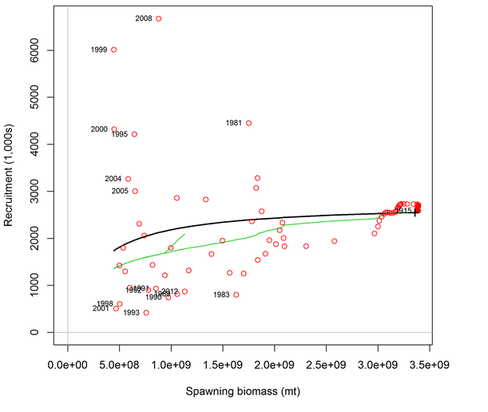

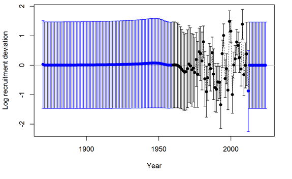

#### 16.2.0.1 Virgin Biomass

The R0 level of recruitment is a parameter of the spawner-recruitment curve. This recruitment and the corresponding spawning biomass are expected to represent the long-term arithmetic mean.

#### 16.2.0.2 Initial Equilibrium

The level of recruitment is typically maintained at the R0 level even though the initial equilibrium catch will reduce the spawning biomass below the virgin level. If steepness is moderately low or the initial F is high, then the lack of response in recruitment level may appear paradoxical. The logic is that building in the spawner-recruitment response to initial F would significantly complicate the calculations and would imply that the initial equilibrium catch level had been going on for multiple generations. If the lack of response is considered to be problematic in a particular application, then start the model at an earlier year and with a lower initial equilibrium catch so that the dynamics of the spawner-recruitment response get captured in the early period, rather than getting lost in the initial equilibrium.

#### 16.2.0.3 Early Data-Poor Period

This is the early part of the time series where the only data typically are landed catch. There are no data to inform the model about the specific year-to-year fluctuations in recruitment, although the ending years of this period will begin to be influenced by the data. The “early time period” is not a formal concept. It is up to the user to decide whether to start estimating recruitment deviations beginning with the first year of the model, or to delay such estimation until the data become more informative. Modeling recruitment deviations in this period may lead to a more realistic portrayal of the uncertainty in depletion, but can also lead to spurious patterns in estimated recruitments that may be driven by the fit to index data or other sources that would not be expected to have accurate information on recruitment.

- Option A: Do not estimate recruitment deviations during this early period. During years prior to the first year of recruitment deviations, the model will set the recruitment equal to the level of the spawner-recruitment curve. Thus, it is a mean-based level of recruitment. Because these annual parameters are fixed to the level of the spawner-recruitment curve, they have no additional uncertainty and make no contribution to the variance of the model. This approach may produce relatively large, or small, magnitude deviations at the very beginning of the subsequent period, as the model “catches up” to any slight signal that could not be captured through estimated deviations in the early data-poor period. There may be some effect on the estimate of R0 as a result of lack of model flexibility in balancing early period removals with signal in the early portion of the data-rich period.
- Option B: Estimate recruitment deviations for all the early years. Each of these recruitment deviations is now a deviation parameter so will have a variance that contributes to the total model variance. The estimated standard deviation of each of these deviation parameters should be similar to $\sigma_R$ because $\sigma_R$ is the only constraint on these parameters (however, the last few in the sequence will begin to feel the effect of the data so may have lower standard deviations).

#### 16.2.0.4 Data-Rich Period

Here the length and or age data inform the model on the year-to-year level of recruitment. These fluctuations in recruitment are assumed to have a lognormal distribution around the log-bias adjusted spawner-recruitment curve. The level of $\sigma_R$ input to the model should match this level of fluctuation to a reasonable degree. Because the recruitments are lognormal, they produce a mean biomass level that is comparable to the virgin biomass and thus the depletion level can be calculated without bias. However, if the early period has recruitment deviations estimated by maximum posterior density, then the depletion levels during the early part of the data-rich period may have some lingering effect of negative bias during the early time period. The level of $\sigma_R$ should be at least as large as the level of variability in these estimated recruitments. If too high a level of $\sigma_R$ is used, then a bias can occur in the estimate of spawner-recruitment steepness, which determines the trend in recruitment. This occurs when the early recruitments are taken directly from the spawner- recruitment curve, so are mean unbiased, then the later recruitments are estimated as deviations from the log-bias adjusted curve. If $\sigma_R$ is too large, then the bias-adjustment is too large, and the model may compensate by increasing steepness to keep the mean level of recent recruitments at the correct level.

#### 16.2.0.5 Recent Years/Forecast

Here the situation is very similar to the early time period in that there are no data to inform the model about the year-to-year pattern in recruitment fluctuations so all deviations will be pulled to a zero level in the maximum posterior density. The structure of SS3 creates no sharp dividing line between the estimation period and the forecast period. In many cases one or more recruitments at the end of the time series will lack appreciable signal in the data and should therefore be treated as forecast recruit deviations. To the degree that some variability is observed in these recruitments, partial or full bias correction may be desirable for these deviations separate from the purely forecast deviations, there is therefore an additional control for the level of bias correction applied to forecast deviations occurring prior to end year + 1.

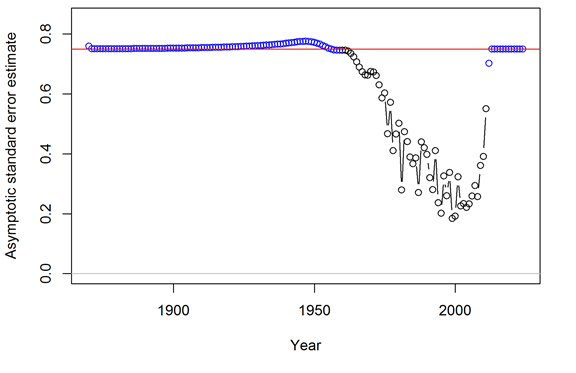

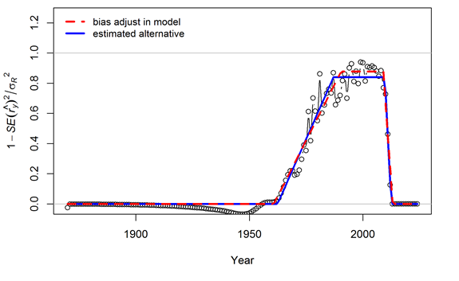

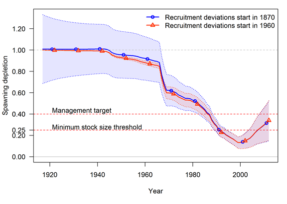

#### 16.2.0.6 Issues with Including Environmental Effects

The expected level of recruitment is a function of spawning biomass, an environmental time series, and a log-bias adjustment.
$$E(Recruitment) = f(SpBio) * exp(\beta*envdata) * exp(-0.5*\sigma_R^2)$$
$\sigma_R$ is the variability of the deviations, so it is in addition to the variance “created” by the environmental effect. So, as more of the total recruitment variability is explained by the environmental effect, the residual $\sigma_R$ should be decreased. The model does not do this automatically.

The environmental effect is inherently lognormal. So when an environmental effect is included in the model, the arithmetic mean recruitment level will be increased above the level predicted by f(SpBio) alone. The consequences of this have not yet been thoroughly investigated, but there probably should be another bias correction based on the variability of the environmental data as scaled by the estimated linkage parameter, $\beta$. It is also problematic that the environmental effect time series used as input is assumed to be measured without error.

The preferred approach to including environmental effects on recruitment is not to use the environmental effect in the direct calculation of the expected level of recruitment. Instead, the environmental data would be used as if it was a survey observation of the recruitment deviation. This approach is similar to using the environmental index as if it was a survey of age 0 recruitment abundance because by focusing on the fit to the deviations it removes the effect of SpBio on recruitment. In this alternative, the $\sigma_R$ would not be changed by the environmental data; instead the environmental data would be used to explain some of the total variability represented by $\sigma_R$. This approach may also allow greater uncertainty in forecasts, as the variability in projected recruitments would reflect both the uncertainty in the environmental observations themselves and the model fit to these observations.

#### 16.2.0.7 Initial Age Composition

If the first year with recruitment deviations is set less than the start year of the model, then these early deviations will modify the initial age composition. The amount of information on historical recruitment variability certainly will degrade as the model attempts to estimate deviations for older age groups in the initial equilibrium. So the degree of bias correction is reduced linearly in proportion to age so that the correction disappears when maximum age is reached. The initial age composition approach normally produces a result that is indistinguishable from a configuration that starts earlier in the time series and estimates a longer time series of recruitments. However, because the initial equilibrium is calculated from a recruitment level unaffected by spawner-recruitment steepness and initial age composition adjustments are applied after the initial equilibrium is calculated, it is possible that the initial age composition approach will produce a slightly different result than if the time series was started earlier and the deviations were being applied to the recruitment levels predicted from the spawner-recruitment curve.

# 17 References